# 3 Multi-state modelling

- Show All Code
- Hide All Code
- View Source

## 1 Learning objectives

**Note**

By the end of this lecture, you should be able to:

- Understand the concepts of **multi-state survival** analysis
- Construct a **state-space** that reflects a multi-state model
- Understand marginal and conditional **multi-state parameters**
- Produce **Nelson-Aalen** estimates for cumulative hazards
- Produce **Aalen-Johansen** estimates for probability in state
- **Restructure** data in preparation for multi-state model analysis
- Apply **Cox proportional hazards** and **flexible parametric models** to estimate covariate effects on transitions

## 2 Basic concepts of multi-state modelling

Multi-state modelling considers that patients are followed up over continuous time period, but are observed to **transition to different states** over the follow-up period.

There are different states where a subject can occupy and possible transitions between these states, represented with arrows. In the simplest form, the **two state survival model**, is how most survival analysis to all-cause death work. The individuals are in an alive state and then we observe their deaths, if they occur.

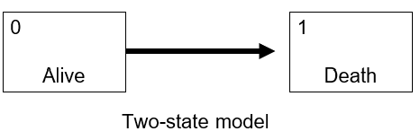

Multi-state models can be considered an extension of **competing risks model**, and are often considered in analogous terms. In competing risks models, we have an initial state and several mutually exclusive absorbing states.

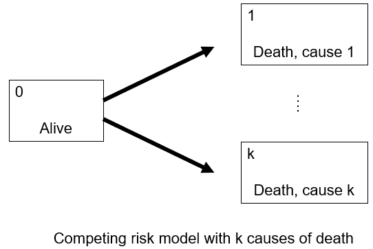

In multi-state models, we have **intermediate states** that are neither initial or absorbing.

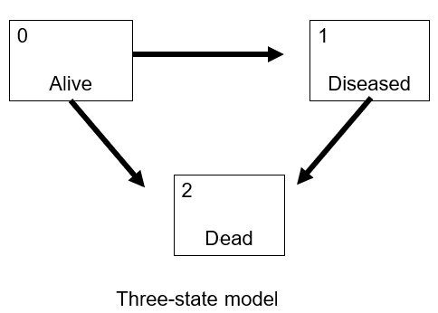

These can also sometimes allow for **recurrent events**.

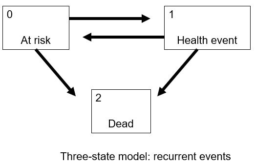

**TipPublished study examples**

We refer to two published study examples that use a multi-state hazards modelling approach: Therneau, TM et al (2024) and De La Mata NL (2024).

## 3 Definitions of multi-state approach

**Defining states:**

- Absorbing states: Subjects will never leave state *h* once entered (e.g. death).
- Transient states: Subjects can move from state *h* to state *j* once entered (e.g. diseased or illness), either once or multiple times.

**Transition times:**

We consider where we can assume we have exact observed transition times, not where events have happened during some interval.

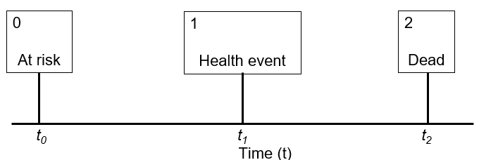

## 4 How can we model multi-state data?

Non-parametric approaches:

- Nelson-Aalen estimator for cumulative hazard
- Aalen-Johansen estimator for state occupation probability

Modelling ‘cause-specific’ hazards:

- Cox proportional ‘cause-specific’ hazards model
- Flexible parametric ‘cause-specific’ hazards model

**WarningAbout Markov multi-state modelling**

We won’t explicitly cover content on Markov multi-state modelling approach, but we will briefly outline instances where they differ.

In general, Markov models are useful in multi-state modelling when exact transition times aren’t known. The Markov assumption is “future states depend solely on the current state, not on sequence of events that preceded it”, i.e. it is memoryless.

## 5 Nelson-Aalen estimator

This is a non-parametric approach to estimate **cumulative transition hazard**, the total cumulative risk of state *h* at time *t*.

If we observe $l \rightarrow j$ transitions at $t$ (i.e. $\Delta N_{lj} (t)>0$), we estimate this conditional transition probability as the ratio of the number $\Delta N_{lj} (t)$ of $l \rightarrow j$ transitions divided by the the number $Y_l (t)$ at risk just prior to transition time $t$. Summing over these increments yields the Nelson-Aalen estimators:

$$\hat{A}_{lj} (t) = \sum_{s \leq t} \frac {\Delta N_{lj} (s)} {Y_l (s)}, l \neq j$$

## 6 Aalen-Johansen estimator

This is a non-parametric approach to estimate **state occupation probability**, the probability (risk) of being in state $h$ at time $t$. It is a matrix version of the Kaplan-Meier estimator.

For each unique time where an event occurs, form the transition matrix $T(t)$ with elements or rates $\lambda\_{ij} (t)$ = the fraction of subjects who transition from state $i$ to $j$ at time $t$, among those in state $i$ just prior to time $t$. Then:

$$p(t) = p(0) \prod_{s \leq t} T(s)$$

Where $p(0)$ is the initial distribution of subjects.

**Note**

The area under the curve for the Aalen-Johansen estimator produces the mean sojourn time in state.

## 7 Transition intensities

These describe the instantaneous risks of transitions betweeen the states (akin to hazard).

Consider $l \rightarrow j$ transition hazard, where $\beta_{lj}$ is a $1 \times p$ vector of regression coefficients, $Z_{i}$ is a $p \times 1$ vector of covariates for individual $i$, and $\alpha_{lj;0}(t)$ is an unspecified, non-negative baseline hazard function.

$$\alpha_{lj;i}(t; Z_{i}) = \alpha_{lj;0}(t) \cdot exp(\beta_{lj}\cdot Z_{i}), l,j\in \{ 0,1,2,...,J\}, l \neq j, i=1,...n$$

**NoteImportant note**

- Depends on time *t* since time origin and on baseline (i.e. time fixed covariates)
- Hazard does not necessary depend on time at which entering current state (i.e. it does not consider the time spent in prior state)
- Assumes common baseline hazard for each transition, regardless of how many times they entered this state before

## 8 Marginal parameters

We have provided here definitions of marginal parameters relevant to multi-state modelling that may be of interest.

**Marginal parameters express:** You place yourself at time $0$ and ask questions about aspects of the multi-state process $V(\cdot)$ at a later time point $t$ (without consideration of what may happen between $0$ and $t$).

- **State occupation probability:** The probability (risk) of being in state $h$ at time $t$.
- **Restricted mean:** The expected time spent in state $h$ being time $t$.
- **Distribution of time** $T_h$ to (first) entry into state $h$ (relevant if everyone starts at time $0$ in the same state $0$).
- **Expected number of events before time *t*:** relevant for recurrent events process $N(\cdot)$, counting the number of events over time.

## 9 Conditional parameters

We have provided here definitions of conditional parameters relevant to multi-state modelling that may be of interest.

**Conditional parameters** for multi-state process $V(\cdot)$ quantify, at time $t$, the future development of the process conditionally on the past of the process before time $t$.

- **Transition intensities:** $\alpha_{lj}(t)$ gives the probability per time unit of moving to state $j$ right after time $t$ given that you are in state $l$ at $t$ and may consider the past up to $t$.
- **Transition probabilities:** $P_{lj}(s,t)$ gives the probability of being in state $j$ at time $t$, given that you were in state $l$ at an earlier time point $s$ and given the past history of $V(\cdot)$ up to that earlier time point (also defined if $l$ and $j$ are the same state).

## 10 Model considerations

There are general considerations when constructing the multi-state model.

- Clinically relevant model versus availability of data to reflect these.
- Too few data for transitions may cause convergence issues.
- Measure of time: origin or study entry, or age or calendar year.

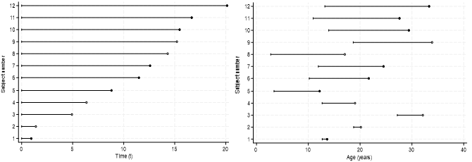

- Clock forward versus clock reset. What this means for interpretation of your model?

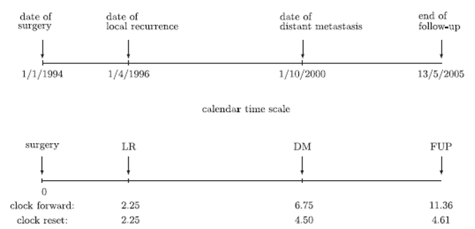

## 11 Worked example: Colon cancer

### 11.1 Data set up

Let’s start with loading the packages and data

**Show R code**

```r
#Load packages
library(readr)
library(dplyr)
library(tidyr)
library(ggplot2)
library(survival)
library(mstate)
library(flexsurv)
library(mvna)

#Load colon cancer data
colon <- survival::colon
```

Below is the list of variables.

id: id  
study: 1 for all patients  
rx: Treatment - Obs(ervation), Lev(amisole), Lev(amisole)+5-FU  
sex: 1=male  
age: in years  
obstruct: obstruction of colon by tumour  
perfor: perforation of colon  
adhere: adherence to nearby organs  
nodes: number of lymph nodes with detectable cancer  
time: days until event or censoring status: censoring status  
differ: differentiation of tumour (1=well, 2=moderate, 3=poor)  
extent: Extent of local spread (1=submucosa, 2=muscle, 3=serosa, 4=contiguous structures)  
surg: time from surgery to registration (0=short, 1=long)  
node4: more than 4 positive lymph nodes  
etype: event type: 1=recurrence, 2=death

We will have a quick look at how the data is set up.

**Show R code**

```r
#View first ten rows of data
print(colon[1:10,])
```

```
   id study      rx sex age obstruct perfor adhere nodes status differ extent
1   1     1 Lev+5FU   1  43        0      0      0     5      1      2      3
2   1     1 Lev+5FU   1  43        0      0      0     5      1      2      3
3   2     1 Lev+5FU   1  63        0      0      0     1      0      2      3
4   2     1 Lev+5FU   1  63        0      0      0     1      0      2      3
5   3     1     Obs   0  71        0      0      1     7      1      2      2
6   3     1     Obs   0  71        0      0      1     7      1      2      2
7   4     1 Lev+5FU   0  66        1      0      0     6      1      2      3
8   4     1 Lev+5FU   0  66        1      0      0     6      1      2      3
9   5     1     Obs   1  69        0      0      0    22      1      2      3
10  5     1     Obs   1  69        0      0      0    22      1      2      3
   surg node4 time etype
1     0     1 1521     2
2     0     1  968     1
3     0     0 3087     2
4     0     0 3087     1
5     0     1  963     2
6     0     1  542     1
7     1     1  293     2
8     1     1  245     1
9     1     1  659     2
10    1     1  523     1
```

Mostly importantly, we see that **id** defines each individual, **time** is given in days and **etype** defines the states of interest.

**Create state space figure**

Some initial data checks should be performed to ensure the times are expected and align with our proposed state space, defined below

**Show R code**

```r
#State space figure
states <- c("Disease-free\n(929)", "Recurrence", "Death")
smat <- matrix(0, 3, 3, dimnames=list(from=states, to=states))
smat[1, 2:3] <- 1; smat[2, 3] <- 1
smat
```

```
                     to
from                  Disease-free\n(929) Recurrence Death
  Disease-free\n(929)                   0          1     1
  Recurrence                            0          0     1
  Death                                 0          0     0
```

**Show R code**

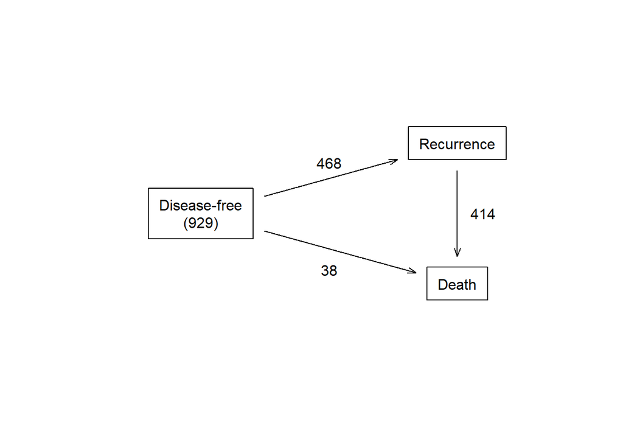

```r
#smat is a matrix with a 1 for any valid transition, 0 otherwise
#| fig-width: 2
#| fig-height: 3
statefig(1:2, smat)

# Add numbers to arrows manually
text(x = 0.5, y = 0.68, labels = "468")
text(x = 0.5, y = 0.3, labels = "38")
text(x = 0.8, y = 0.5, labels = "414")
```

**Check for tied times**

We will now check that there are not times are not tied and, if so, fix the times tied so recurrence occur prior to death.

**Show R code**

```r
#Divide the data into the two states
c1 <- subset(colon, etype== 1) # recurrence
c2 <- subset(colon, etype== 2) # death

#Check for tied times
tied.id <- (c1$time == c2$time & c1$status==1 & c2$status==1)
table(tied.id)
```

```
tied.id
FALSE  TRUE
  924     5
```

**Show R code**

```r
# There are 5 subjects with recurrence coded on the same day as death.
# Make them recur one day earlier than their death (avoid 0 length intervals)
c1$time[tied.id] <- c1$time[tied.id] -1
```

**TipHint**

Other important data checks for time include checking preceding and proceeding states (e.g. death is always the state with the maximum time), deciding order of events when tied times, and censoring event times.

Create a dataset that consecutive times, running from **time1** to **time2**, and **state** variable indicating which event occured.

**Show R code**

```r
# Create the counting process dataset
cdata <- tmerge(subset(c2, ,-c(study, time, status, etype)),
c2, id=id, death= event(time, status),
options=list(tstart="time1", tstop="time2"))
cdata <- tmerge(cdata, c1, id= id, recur= event(time, status),
td.recur = tdc(time))

#Check transitions
table(cdata$recur, cdata$death)
```

```
      0   1
  0 475 452
  1 468   0
```

**Show R code**

```r
# The table above verifies no tied event times
# Make the state variable
cdata$state <- with(cdata, factor(recur+ 2*death, 0:2,
c("censor", "recur", "death")))
```

We then proceed with re-adjusting the variables included to prepare for modelling, including the time variable from days to years.

**Show R code**

```r
# Create some simple variables
cdata$age10 <- cdata$age/10 # age in decades
cdata$male <- 1*(cdata$sex ==1) # 0/1: male
cdata$trt <- 1*(cdata$rx == "Lev+5FU")
# a 0/1 treatment variable, 1=Lev+5FU, 0= Observation or Lev
# Output in years gives simpler plots
cdata$time1 <- cdata$time1/365.25
cdata$time2 <- cdata$time2/365.25
```

We can check the **time1**, **time2** and **state** variables are working as we expected.

**Show R code**

```r
# Check for consistency
check <-survcheck(Surv(time1, time2, state) ~ 1, cdata, id=id)
check
```

```
Call:
survcheck(formula = Surv(time1, time2, state) ~ 1, data = cdata,
    id = id)

Unique identifiers       Observations        Transitions
               929               1395                920

Transitions table:
       to
from    recur death (censored)
  (s0)    468    38        423
  recur     0   414         52
  death     0     0          0

Number of subjects with 0, 1, ... transitions to each state:
       count
state     0   1   2
  recur 461 468   0
  death 477 452   0
  (any) 423  92 414
```

### 11.2 Nelson-Aalen estimates

Now our data is ready to produce some estimates. Let’s start with Nelson-Aalen.

**Show R code**

```r
# Matrix of logical giving the possible transitions
tra <- matrix(ncol=3,nrow=3,FALSE)
tra[1, 2:3] <- TRUE
tra[2, 3] <- TRUE

#Select & prepare relevant data
cdata_na <- cdata %>% select(id, time1, time2, state) %>%
  group_by(id) %>%
  mutate(seq=row_number()) %>%  ungroup() %>%
  mutate(
  from = factor(case_when(
    time1 == 0 ~ "entry",
    seq == 2 ~ "recur"), levels = c("entry", "recur")),
  to = factor(case_when(
    state=="recur" ~ "recur",
    state=="death" ~ "death",
    state=="censor" ~ "cens"
  ), levels = c("recur", "death", "cens")
), time = time2) %>%
  select(-seq, -state, -time1, -time2)

#Nelson-Aalen estimates
na <- mvna(cdata_na, c("entry", "recur", "death"), tra, "cens")
na
```

```
Transition entry -> recur
   na var.aalen var.greenwood time
 0.00         0             0 0.00
 0.36         0             0 1.36
 0.60         0             0 3.24
 0.71         0             0 6.05
 0.72         0             0 7.12
 0.73         0             0 9.10

Transition entry -> death
   na var.aalen var.greenwood time
 0.00         0             0 0.00
 0.01         0             0 1.36
 0.03         0             0 3.24
 0.06         0             0 6.05
 0.08         0             0 7.12
 0.11         0             0 9.10

Transition recur -> death
   na var.aalen var.greenwood time
 0.00      0.00          0.00 0.02
 1.35      0.06          0.05 1.36
 2.59      0.07          0.06 3.19
 3.84      0.09          0.08 6.03
 4.10      0.10          0.09 7.09
 4.64      0.22          0.18 8.74
```

**Show R code**

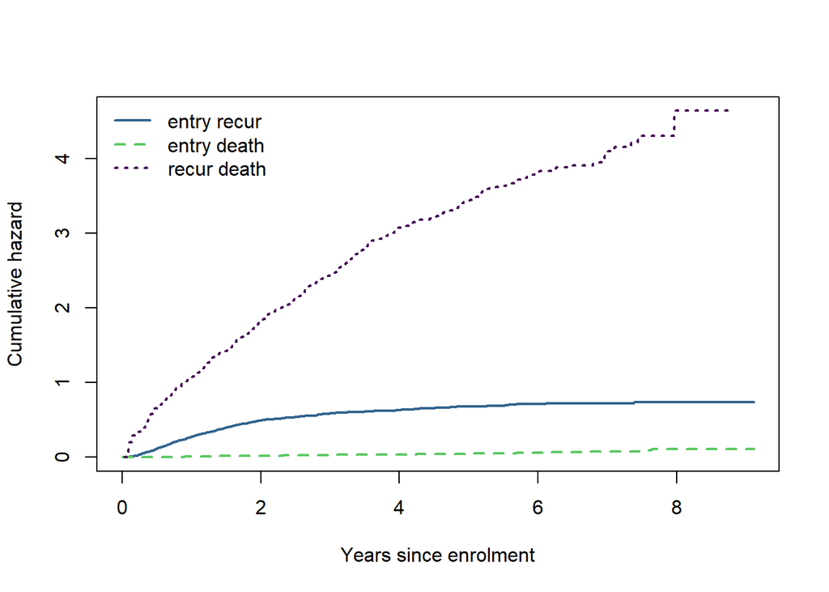

```r
#Graph settings
mycolor <- c("#440154FF","#32648EFF","#21908CFF","#5DC863FF","#DCE318FF","#FFFFFF")
opar <- par(no.readonly = TRUE)

#Cumulative hazard - days since enrolment
#| fig-width: 2
#| fig-height: 3
plot(na, lwd=2, col=mycolor[c(2,4, 1)],
xlab="Years since enrolment", ylab="Cumulative hazard")
```

The cumulative hazard rapidly increases for the transition from recurrence to death, at a much greater rate than from entry to death, and consistently increasing over time. For the transition from entry to recurrence, we see an initial increase which subsequently plateaus.

### 11.3 Aalen-Johansen estimates

Let’s move on to produce Aalen-Johansen estimates.

**Show R code**

```r
#Aalen-Johansen estimates
aj0 <- survfit(Surv(time1, time2, state) ~1, data=cdata, id=id) # overall
aj0
```

```
Call: survfit(formula = Surv(time1, time2, state) ~ 1, data = cdata,
    id = id)

         n nevent     rmean se(rmean)*
(s0)  1395      0 4.9873049 0.12778638
recur 1395    468 0.8335835 0.05280062
death 1395    452 3.2934169 0.11519825
   *restricted mean time in state (max time = 9.114305 )
```

**Show R code**

```r
aj1 <- survfit(Surv(time1, time2, state) ~ trt, data=cdata, id=id) # by arm
aj1
```

```
Call: survfit(formula = Surv(time1, time2, state) ~ trt, data = cdata,
    id = id)

               n nevent     rmean se(rmean)*
trt=0, (s0)  972      0 4.5660978 0.15531180
trt=1, (s0)  423      0 5.8438504 0.21605777
trt=0, recur 972    349 0.9779533 0.06823020
trt=1, recur 423    119 0.5424381 0.07543991
trt=0, death 972    329 3.5702541 0.14090922
trt=1, death 423    123 2.7280167 0.19469518
   *restricted mean time in state (max time = 9.114305 )
```

**Show R code**

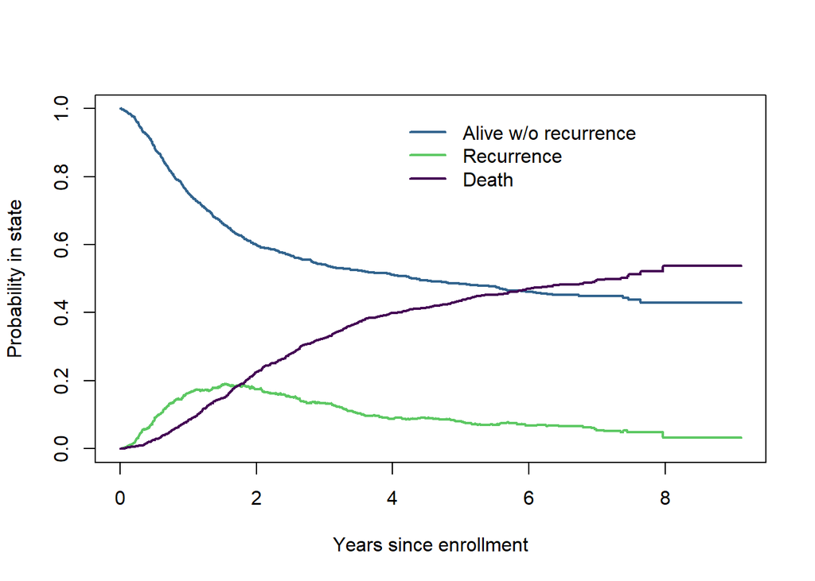

```r
#Graph settings
mycolor <- c("#440154FF","#32648EFF","#21908CFF","#5DC863FF","#DCE318FF","#FFFFFF")
opar <- par(no.readonly = TRUE)

#Probability in state graphs - overall
#| fig-width: 2
#| fig-height: 3
plot(aj0, noplot=NULL, lwd=2, col=mycolor[c(2,4, 1)],
xlab="Years since enrollment", ylab="Probability in state")
# the noplot=NULL option results in s(0) line being plotted
legend(4, 1, c("Alive w/o recurrence", "Recurrence", "Death"), lwd=2,
col=mycolor[c(2, 4, 1)], bty='n')
```

**Show R code**

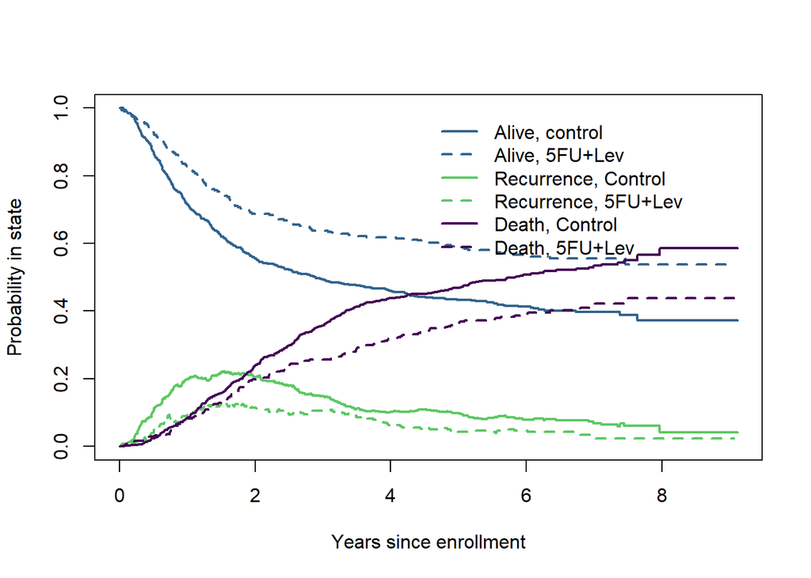

```r
#Probability in state graphs - by treatment
#| fig-width: 2
#| fig-height: 3
plot(aj1, noplot=NULL, lwd=2, lty=1:2, col=mycolor[c(2,2,4,4,1,1)],
xlab="Years since enrollment", ylab="Probability in state")
legend(4.5, 1, c("Alive, control", "Alive, 5FU+Lev",  "Recurrence, Control", "Recurrence, 5FU+Lev",
"Death, Control", "Death, 5FU+Lev"),
lwd=2, lty=1:2, col=mycolor[c(2,2,4,4,1,1)], bty='n')
```

The estimated probability in state conincides with patterns we saw in the cumulative hazard. Probability for death increases over time, resulting in lower probability of being alive without recurrence. Further, we see the probability of recurrence peaks in the first two years (where the cumulative hazard rapidly increases), before reducing over time.

Producing the expected time in state also can call upon these output from survfit(). We can also add more covariates to see how the expected mean time changes.

**Show R code**

```r
#Expected time in state
print(aj1, rmean= 8, digits=2) #print sojourn time restricted to 8 years
```

```
Call: survfit(formula = Surv(time1, time2, state) ~ trt, data = cdata,
    id = id)

               n nevent rmean se(rmean)*
trt=0, (s0)  972      0  4.15      0.133
trt=1, (s0)  423      0  5.24      0.186
trt=0, recur 972    349  0.93      0.059
trt=1, recur 423    119  0.52      0.066
trt=0, death 972    329  2.92      0.118
trt=1, death 423    123  2.24      0.165
   *restricted mean time in state (max time = 8 )
```

**Show R code**

```r
#Adjusted AJ for expected times
aj2 <- survfit(Surv(time1, time2, state) ~ trt+male, data=cdata, id=id) # by arm
aj2
```

```
Call: survfit(formula = Surv(time1, time2, state) ~ trt + male, data = cdata,
    id = id)

                       n nevent     rmean se(rmean)*
trt=0, male=0, (s0)  436      0 4.7028792 0.23348248
trt=0, male=1, (s0)  536      0 4.4235985 0.20062003
trt=1, male=0, (s0)  237      0 5.3133965 0.30250975
trt=1, male=1, (s0)  186      0 6.4438228 0.30058240
trt=0, male=0, recur 436    155 1.0909907 0.10914506
trt=0, male=1, recur 536    194 0.9180868 0.08140726
trt=1, male=0, recur 237     74 0.6748420 0.11564951
trt=1, male=1, recur 186     45 0.3881854 0.07285675
trt=0, male=0, death 436    140 3.3204354 0.20731102
trt=0, male=1, death 536    189 3.7726200 0.18362128
trt=1, male=0, death 237     75 3.1260668 0.27477660
trt=1, male=1, death 186     48 2.2822971 0.26726999
   *restricted mean time in state (max time = 9.114305 )
```

**Show R code**

```r
#Print expected times
print(aj2, rmean= 8, digits=2) #print sojourn time restricted to 8 years
```

```
Call: survfit(formula = Surv(time1, time2, state) ~ trt + male, data = cdata,
    id = id)

                       n nevent rmean se(rmean)*
trt=0, male=0, (s0)  436      0  4.24      0.202
trt=0, male=1, (s0)  536      0  4.07      0.177
trt=1, male=0, (s0)  237      0  4.76      0.263
trt=1, male=1, (s0)  186      0  5.79      0.256
trt=0, male=0, recur 436    155  1.01      0.095
trt=0, male=1, recur 536    194  0.87      0.074
trt=1, male=0, recur 237     74  0.63      0.102
trt=1, male=1, recur 186     45  0.39      0.073
trt=0, male=0, death 436    140  2.75      0.176
trt=0, male=1, death 536    189  3.06      0.160
trt=1, male=0, death 237     75  2.61      0.236
trt=1, male=1, death 186     48  1.82      0.223
   *restricted mean time in state (max time = 8 )
```

We see that rmean adds up to 8 for each stratum created. However, it can becomes problematic to calculate expected mean times in state using Aalen-Johansen if you’d like to adjust for many other factors. The covariates function as stratum, and so begin to split the data and events quite rapidly. We also don’t have the functionality to create a new dataframe to predict upon when using Aalen-Johansen (we will see how we can do this using Cox or flexible parametric).

### 11.4 Cox proportional ‘cause specific’ hazards model

Now, let’s fit a multistate hazards model (i.e. Cox proportional hazards).

**Show R code**

```r
# fit the model
cfit <- coxph(Surv(time1, time2, state) ~ trt +age10 + male + extent + node4,
data=cdata, id=id)
print(cfit, digits=2)
```

```
Call:
coxph(formula = Surv(time1, time2, state) ~ trt + age10 + male +
    extent + node4, data = cdata, id = id)


1:2        coef exp(coef) se(coef) robust se    z      p
  trt    -0.507     0.602    0.106     0.108 -4.7  3e-06
  age10  -0.032     0.969    0.039     0.042 -0.8    0.5
  male   -0.089     0.915    0.093     0.095 -0.9    0.3
  extent  0.532     1.703    0.113     0.122  4.4  1e-05
  node4   0.835     2.305    0.096     0.100  8.4 <2e-16


1:3      coef exp(coef) se(coef) robust se   z     p
  trt    0.02      1.02     0.34      0.34 0.1   1.0
  age10  0.88      2.40     0.20      0.19 4.6 4e-06
  male   0.45      1.57     0.34      0.34 1.3   0.2
  extent 0.47      1.60     0.39      0.51 0.9   0.4
  node4  0.64      1.90     0.38      0.39 1.6   0.1


2:3       coef exp(coef) se(coef) robust se   z     p
  trt    0.288     1.334    0.114     0.119 2.4  0.02
  age10  0.105     1.111    0.040     0.044 2.4  0.02
  male   0.196     1.216    0.101     0.094 2.1  0.04
  extent 0.084     1.088    0.106     0.112 0.8  0.45
  node4  0.434     1.544    0.104     0.101 4.3 2e-05

 States:  1= (s0), 2= recur, 3= death

Likelihood ratio test=189  on 15 df, p=<2e-16
n= 1395, unique id= 929, number of events= 920
```

**Show R code**

```r
summary(cfit)
```

```
Call:
coxph(formula = Surv(time1, time2, state) ~ trt + age10 + male +
    extent + node4, data = cdata, id = id)

  n= 1395, number of events= 920

               coef exp(coef) se(coef) robust se      z Pr(>|z|)
trt_1:2    -0.50732   0.60211  0.10645   0.10788 -4.703 2.57e-06 ***
age10_1:2  -0.03171   0.96879  0.03902   0.04199 -0.755   0.4502
male_1:2   -0.08858   0.91523  0.09271   0.09454 -0.937   0.3488
extent_1:2  0.53249   1.70316  0.11332   0.12223  4.356 1.32e-05 ***
node4_1:2   0.83503   2.30489  0.09614   0.09975  8.371  < 2e-16 ***
trt_1:3     0.02025   1.02046  0.33595   0.33520  0.060   0.9518
age10_1:3   0.87475   2.39829  0.19574   0.19049  4.592 4.39e-06 ***
male_1:3    0.45226   1.57186  0.33650   0.34432  1.313   0.1890
extent_1:3  0.46911   1.59858  0.38750   0.50819  0.923   0.3559
node4_1:3   0.64311   1.90238  0.37459   0.39068  1.646   0.0997 .
trt_2:3     0.28841   1.33431  0.11431   0.11860  2.432   0.0150 *
age10_2:3   0.10482   1.11051  0.03995   0.04354  2.407   0.0161 *
male_2:3    0.19550   1.21592  0.10079   0.09393  2.081   0.0374 *
extent_2:3  0.08431   1.08797  0.10604   0.11154  0.756   0.4497
node4_2:3   0.43444   1.54409  0.10423   0.10092  4.305 1.67e-05 ***
---
Signif. codes:  0 '***' 0.001 '**' 0.01 '*' 0.05 '.' 0.1 ' ' 1

           exp(coef) exp(-coef) lower .95 upper .95
trt_1:2       0.6021     1.6608    0.4874    0.7439
age10_1:2     0.9688     1.0322    0.8922    1.0519
male_1:2      0.9152     1.0926    0.7604    1.1015
extent_1:2    1.7032     0.5871    1.3403    2.1642
node4_1:2     2.3049     0.4339    1.8956    2.8026
trt_1:3       1.0205     0.9799    0.5290    1.9684
age10_1:3     2.3983     0.4170    1.6510    3.4837
male_1:3      1.5719     0.6362    0.8004    3.0867
extent_1:3    1.5986     0.6256    0.5904    4.3282
node4_1:3     1.9024     0.5257    0.8846    4.0911
trt_2:3       1.3343     0.7495    1.0575    1.6835
age10_2:3     1.1105     0.9005    1.0197    1.2094
male_2:3      1.2159     0.8224    1.0115    1.4617
extent_2:3    1.0880     0.9191    0.8743    1.3538
node4_2:3     1.5441     0.6476    1.2670    1.8818

Concordance= 0.647  (se = 0.011 )
Likelihood ratio test= 188.5  on 15 df,   p=<2e-16
Wald test            = 173.9  on 15 df,   p=<2e-16
Score (logrank) test = 191.6  on 15 df,   p=<2e-16,   Robust = 154.6  p=<2e-16

  (Note: the likelihood ratio and score tests assume independence of
     observations within a cluster, the Wald and robust score tests do not).
```

The multivariate model allows us to assess the covariate effects on the transitions. For example, the treatment effect from transition 1 (Disease-free) to 2 (Recurrence) has HR estimate of 0.60 (95%CI: 0.49, 0.74) and for transition 2 (Recurrence) to 3 (Death) has HR estimate of 1.33 (95%CI: 1.06, 1.68).

We can create a forest plot of the HR estimates and their 95%CI.

**Show R code**

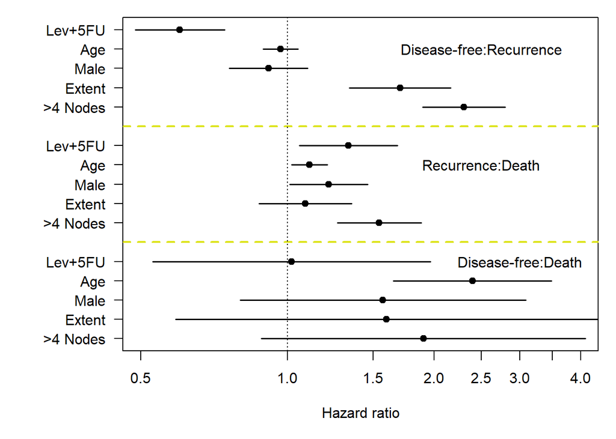

```r
# get the HR, and lower and upper limit
temp <- summary(cfit)$conf.int[ , c(1,3,4)]

# generate the forest plot
par(mar=c(5,7, 1, 1)) # more room for y axis labels
yy <- c(outer(5:1, c(12, 0, 6), "+"))

#| fig-width: 2
#| fig-height: 3
plot(c(.5,4), range(yy), log='x', type="n", xlab="Hazard ratio", ylab="", yaxt= 'n')
axis(2, at=yy, label=rep(c("Lev+5FU", "Age", "Male", "Extent", ">4 Nodes") ,3), las=2)
points(temp[,1], yy, pch=19)
segments(temp[,2], yy, temp[,3], yy, lwd=1.5)
abline(h=c(6,12), lwd=2, lty=2, col=mycolor[5])
abline(v=1, lty=3)
text(c(2.5, 2.5, 3), c(16, 10, 5), c("Disease-free:Recurrence", "Recurrence:Death",
"Disease-free:Death"))
```

We can run similar checks on the Cox proportional hazards model, such as the proportionality test below.

**Show R code**

```r
#Proportional hazards test
ph_test <- cox.zph(cfit)
ph_test
```

```
             chisq df      p
trt_1:2     0.0225  1 0.8806
age10_1:2   0.2132  1 0.6443
male_1:2    3.2844  1 0.0699
extent_1:2  0.4149  1 0.5195
node4_1:2  10.3456  1 0.0013
trt_1:3     0.3828  1 0.5361
age10_1:3   0.8400  1 0.3594
male_1:3    0.0126  1 0.9106
extent_1:3  0.1140  1 0.7356
node4_1:3   1.5076  1 0.2195
trt_2:3     2.6383  1 0.1043
age10_2:3   1.4179  1 0.2337
male_2:3    0.1326  1 0.7157
extent_2:3  2.5355  1 0.1113
node4_2:3   0.2728  1 0.6015
GLOBAL     24.0919 15 0.0635
```

We can use this model to produce predicted probability in state and expected time in state. For this example, we have simplified the model to replicate the barplot in the paper. However, you can create your own combinations for the covariates.

**Show R code**

```r
#Simplified model
cfit2 <- coxph(Surv(time1, time2, state) ~ trt + extent + node4, data=cdata, id=id)

#Create dummy data
dummy <- expand.grid(trt=0:1, extent=1:4, node4= 0:1) # 16 combinations

# Predicted probability in state from the MSH model
csurv2 <- survfit(cfit2, newdata=dummy) # 16 predicted curves
```

The resulting csurv2 does produce probability in state from the Cox model, but this is only until the max time in the original patient dataset (cdata) and against the 16 combinations.

**Show R code**

```r
# calculate the sojourn time and assemble it into a matrix
temp <- summary(csurv2, rmean=8)$table[,"rmean"]
sojourn <- matrix(temp, 16, 3,
dimnames=list(NULL, c("disease-free", "recurrence", "death")))
sdata <- cbind(dummy, round(sojourn,2)) # add this to the dummy data frame
sdata
```

```
   trt extent node4 disease-free recurrence death
1    0      1     0         6.57       0.49  0.94
2    1      1     0         7.04       0.25  0.70
3    0      2     0         5.75       0.70  1.55
4    1      2     0         6.47       0.37  1.16
5    0      3     0         4.62       0.94  2.44
6    1      3     0         5.61       0.52  1.86
7    0      4     0         3.26       1.16  3.58
8    1      4     0         4.46       0.69  2.86
9    0      1     1         5.17       0.70  2.13
10   1      1     1         6.05       0.37  1.57
11   0      2     1         3.89       0.89  3.22
12   1      2     1         5.03       0.51  2.46
13   0      3     1         2.50       1.00  4.49
14   1      3     1         3.73       0.63  3.64
15   0      4     1         1.36       0.99  5.64
16   1      4     1         2.36       0.69  4.94
```

We can see for each combination of covariates in our dummy data, we have the predicted expected time in state, which adds up to 8 years across the three states. The below summarises the expected time in state into a bar plot.

**Show R code**

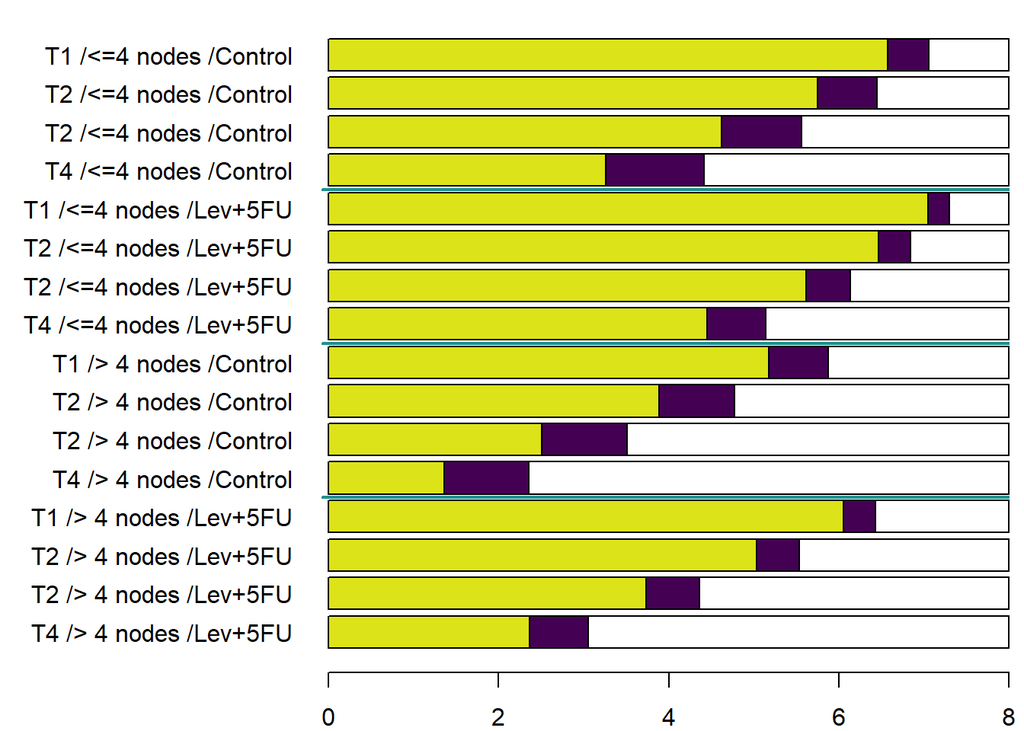

```r
# plot the sojourn
rownames(sojourn) <- paste(
rep(rep(c("T1", "T2", "T2", "T4"), each=2),2), rep(c("/<=4 nodes","/> 4 nodes"), each=8),
rep(c("/Control", "/Lev+5FU"), 8))

# put the controls together
xx <- rev(c(1,3,5,7,2,4,6,8))
xx <- c(xx+8, xx)
par(mar=c(2, 11, 0.5, 0.5))

#| fig-width: 2
#| fig-height: 3
barplot(t(sojourn[xx,]), horiz=TRUE, col=mycolor[c(5, 1, 6)],
las=1)
abline(h=c(4.9, 9.7,14.5), lwd=2, col=mycolor[3])
```

### 11.5 mstate package

We can also use the mstate package and to produce similar non-parametric estimates (i.e. cumulative hazard and probability in state) and subsequent functionality with flexsurv and coxph.

First we will create the transition matrix, which assigns a consecutive number to each of the transitions and list the element where the transition exists in each row of the matrix. This functions differently to the above, which was mostly aesthetic and to understand the data layout.

Let’s say instead we had our dataset in a wide format, one line per individual and separate variables for time to each state and status to each state. We can reshape our c1 and c2 datasets to create this hypothetical dataset.

**Show R code**

```r
#Wide dataset for colon
cdata_wide <- c1 %>% rename(time_recur = time,
                            status_recur = status) %>%
  select(id, time_recur, status_recur) %>%
      left_join(c2, by="id") %>% select(-etype) %>%
  rename(time_death = time, status_death = status)

#Print data
print(cdata_wide[1:10,])
```

```
   id time_recur status_recur study      rx sex age obstruct perfor adhere
1   1        968            1     1 Lev+5FU   1  43        0      0      0
2   2       3087            0     1 Lev+5FU   1  63        0      0      0
3   3        542            1     1     Obs   0  71        0      0      1
4   4        245            1     1 Lev+5FU   0  66        1      0      0
5   5        523            1     1     Obs   1  69        0      0      0
6   6        904            1     1 Lev+5FU   0  57        0      0      0
7   7        229            1     1     Lev   1  77        0      0      0
8   8       3192            0     1     Obs   1  54        0      0      0
9   9       3173            0     1     Lev   1  46        0      0      1
10 10       3308            0     1 Lev+5FU   0  68        0      0      0
   nodes status_death differ extent surg node4 time_death
1      5            1      2      3    0     1       1521
2      1            0      2      3    0     0       3087
3      7            1      2      2    0     1        963
4      6            1      2      3    1     1        293
5     22            1      2      3    1     1        659
6      9            1      2      3    0     1       1767
7      5            1      2      3    1     1        420
8      1            0      2      3    0     0       3192
9      2            0      2      3    0     0       3173
10     1            0      2      3    1     0       3308
```

We could use msprep in the mstate package to help reshape our data into long format for a multi state analysis. We first define the transition matrix and then run the msprep.

**Show R code**

```r
#Transition matrix
tmat <- transMat(x = list(c(2,3), c(3), c()), names=c("Alive", "Recurrence", "Death"))

#Check time_death and time_recur are not equal
cdata_wide %>% filter(time_recur>=time_death & status_recur==1) %>% print()
```

```
   id time_recur status_recur study  rx sex age obstruct perfor adhere nodes
1 239       2695            1     1 Obs   1  76        0      0      0     1
2 602       1918            1     1 Lev   0  69        0      0      1    19
  status_death differ extent surg node4 time_death
1            0      2      3    0     0       2695
2            0      2      3    0     1       1918
```

**Show R code**

```r
#Adjust by one day so recur occurs one day earlier
cdata_wide <- cdata_wide %>%
  mutate(time_recur = case_when(
    id %in% c(239, 602) ~ time_recur-1,
    TRUE ~ time_recur
  ))

#Reshape using msprep
cdata_long <- msprep(data=cdata_wide, trans=tmat, time=c(NA, "time_recur", "time_death"), status=c(NA, "status_recur", "status_death"), keep=c("rx", "sex", "age", "obstruct", "perfor", "adhere", "nodes", "differ", "extent", "surg", "node4"))
```

Let’s now fit Cox model without any covariates, so we define a baseline hazards for each transition and then use msfit() to produce the cumulative hazards. You’ll see this equates to the Nelson-Aalen estimates of cumulative hazard produced above.

**Show R code**

```r
#Convert time to years since enrolment
cdata_long$Tstart <- cdata_long$Tstart/365.25
cdata_long$Tstop <- cdata_long$Tstop/365.25
cdata_long$age10 <- cdata_long$age/10 # age in decades
cdata_long$male <- 1*(cdata_long$sex ==1) # 0/1: male
cdata_long$trt <- 1*(cdata_long$rx == "Lev+5FU")

#Fit Cox model with separate baseline hazards for each transition
cfit_mstate <- coxph(Surv(Tstart, Tstop, status) ~ strata(trans),
data=cdata_long, id=id)
print(cfit_mstate, digits=2)
```

```
Call:  coxph(formula = Surv(Tstart, Tstop, status) ~ strata(trans),
    data = cdata_long, id = id)

Null model
  log likelihood= -5233.511
  n= 2326
```

**Show R code**

```r
summary(cfit_mstate)
```

```
Call:  coxph(formula = Surv(Tstart, Tstop, status) ~ strata(trans),
    data = cdata_long, id = id)

Null model
  log likelihood= -5233.511
  n= 2326
```

**Show R code**

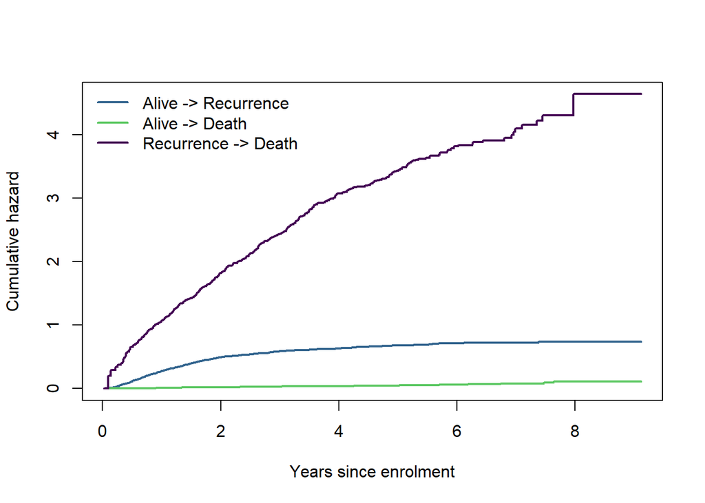

```r
#Cumulative hazards
msfit_mstate <- msfit(cfit_mstate, trans=tmat)

#Graph settings
mycolor <- c("#440154FF","#32648EFF","#21908CFF","#5DC863FF","#DCE318FF","#FFFFFF")

#Plot of cumulative hazards
#| fig-width: 2
#| fig-height: 3
plot(msfit_mstate, lwd=2, col=mycolor[c(2,4, 1)],
xlab="Years since enrolment", ylab="Cumulative hazard")
```

Similarly, we can apply the probtrans() function to produce the transition probabilities. You’ll see this equates to the Aalen-Johansen estimates of probability in state produced.

**Show R code**

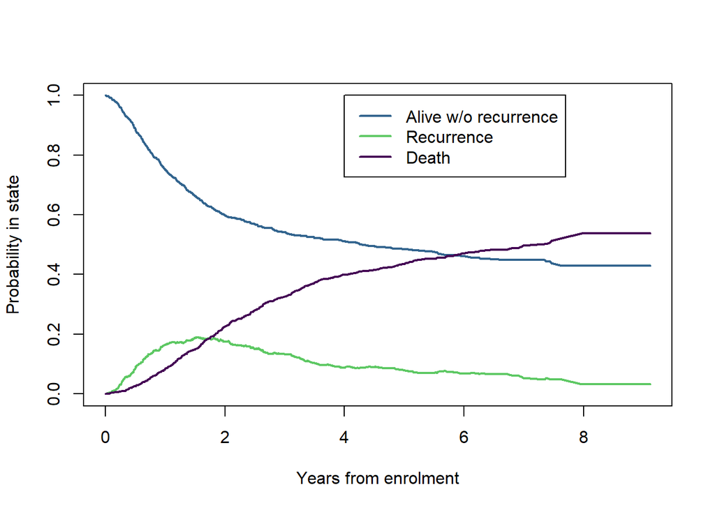

```r
#Probabilities in state
pr0 <- probtrans(msfit_mstate, predt = 0)

#From entry to other states
pr0_from1 <- pr0[[1]]

#Plot of probabilities in state
#| fig-width: 2
#| fig-height: 3
matplot(pr0_from1$time, pr0_from1[, grep("^pstate", names(pr0_from1))], type = "l", lwd=2, lty = 1, xlab = "Years from enrolment", ylab = "Probability in state", col=mycolor[c(2,4, 1)])
legend(4,1,
       legend = c("Alive w/o recurrence", "Recurrence", "Death"),
       col = mycolor[c(2, 4, 1)],
       lty = 1, lwd=2)
```

Now, the above has fitted the transitions using the strata() option and specifying the trans produced in the msprep. Fitting trans in a stratum means the covariate effects are assumed to be common amongst the transitions. This may or may not reflect the reality or what you’d like to produce findings on. We will now describe how we can fit transition-specific covariates.

**Show R code**

```r
#Expand covariates to fit transition-specific covariates
covs <- c("trt", "age10", "male", "extent", "node4")
cdata_long_exp <- expand.covs(cdata_long, covs, longnames=FALSE)

#Fit cox model with transition specific covariates
cfit_tspec_strata <- coxph(Surv(Tstart, Tstop, status) ~ trt.1 + trt.2 + trt.3 + age10.1 + age10.2 + age10.3 + male.1 + male.2 + male.3 + extent.1 + extent.2 + extent.3 + node4.1 + node4.2 + node4.3 + strata(trans),
data=cdata_long_exp, id=id)
summary(cfit_tspec_strata)
```

```
Call:
coxph(formula = Surv(Tstart, Tstop, status) ~ trt.1 + trt.2 +
    trt.3 + age10.1 + age10.2 + age10.3 + male.1 + male.2 + male.3 +
    extent.1 + extent.2 + extent.3 + node4.1 + node4.2 + node4.3 +
    strata(trans), data = cdata_long_exp, id = id)

  n= 2326, number of events= 920

             coef exp(coef) se(coef) robust se      z Pr(>|z|)
trt.1    -0.50755   0.60197  0.10645   0.10792 -4.703 2.57e-06 ***
trt.2     0.02025   1.02046  0.33595   0.33520  0.060   0.9518
trt.3     0.28848   1.33440  0.11431   0.11873  2.430   0.0151 *
age10.1  -0.03166   0.96883  0.03902   0.04202 -0.754   0.4511
age10.2   0.87475   2.39829  0.19574   0.19049  4.592 4.39e-06 ***
age10.3   0.10489   1.11059  0.03995   0.04358  2.407   0.0161 *
male.1   -0.08880   0.91503  0.09270   0.09459 -0.939   0.3478
male.2    0.45226   1.57186  0.33650   0.34432  1.313   0.1890
male.3    0.19556   1.21599  0.10079   0.09401  2.080   0.0375 *
extent.1  0.53260   1.70336  0.11332   0.12229  4.355 1.33e-05 ***
extent.2  0.46911   1.59858  0.38750   0.50819  0.923   0.3559
extent.3  0.08427   1.08793  0.10602   0.11158  0.755   0.4501
node4.1   0.83555   2.30607  0.09614   0.09983  8.370  < 2e-16 ***
node4.2   0.64311   1.90238  0.37459   0.39068  1.646   0.0997 .
node4.3   0.43511   1.54513  0.10423   0.10102  4.307 1.65e-05 ***
---
Signif. codes:  0 '***' 0.001 '**' 0.01 '*' 0.05 '.' 0.1 ' ' 1

         exp(coef) exp(-coef) lower .95 upper .95
trt.1       0.6020     1.6612    0.4872    0.7438
trt.2       1.0205     0.9799    0.5290    1.9684
trt.3       1.3344     0.7494    1.0574    1.6840
age10.1     0.9688     1.0322    0.8922    1.0520
age10.2     2.3983     0.4170    1.6510    3.4837
age10.3     1.1106     0.9004    1.0197    1.2096
male.1      0.9150     1.0929    0.7602    1.1014
male.2      1.5719     0.6362    0.8004    3.0867
male.3      1.2160     0.8224    1.0114    1.4620
extent.1    1.7034     0.5871    1.3403    2.1647
extent.2    1.5986     0.6256    0.5904    4.3282
extent.3    1.0879     0.9192    0.8742    1.3539
node4.1     2.3061     0.4336    1.8963    2.8044
node4.2     1.9024     0.5257    0.8846    4.0911
node4.3     1.5451     0.6472    1.2676    1.8835

Concordance= 0.647  (se = 0.011 )
Likelihood ratio test= 188.7  on 15 df,   p=<2e-16
Wald test            = 173.8  on 15 df,   p=<2e-16
Score (logrank) test = 191.8  on 15 df,   p=<2e-16,   Robust = 154.5  p=<2e-16

  (Note: the likelihood ratio and score tests assume independence of
     observations within a cluster, the Wald and robust score tests do not).
```

These coefficient estimates are nearly exactly the same as produced by the coxph() above when state was specified in the Surv() function.

From the output, we can produce the cumulative hazard against covariate patterns. In this case, we focus on the treatment effect and plot these.

**Show R code**

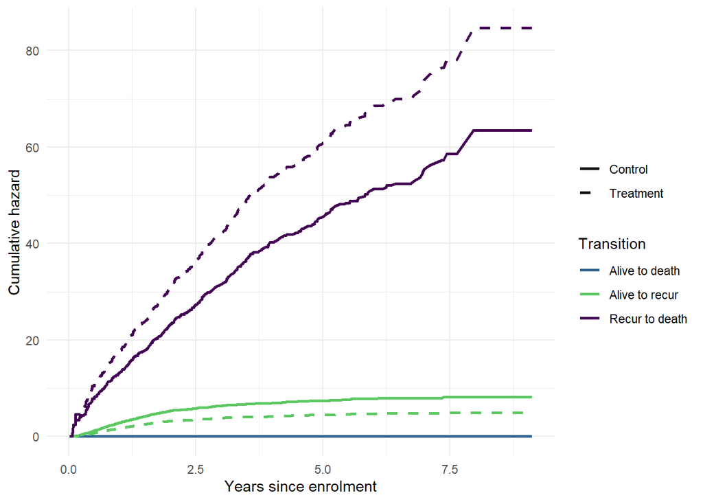

```r
#Newdata to predict on - ref levels
newdata_tspec0 <- data.frame(
  trans=1:3,
  strata=1:3,
  trt.1 = c(0,0,0),
  age10.1=c(4,4,4),
  male.1=c(0,0,0),
  extent.1 = c(0,0,0),
  node4.1 = c(0,0,0),
  trt.2 = c(0,0,0),
  age10.2=c(4,4,4),
  male.2=c(0,0,0),
  extent.2 = c(0,0,0),
  node4.2 = c(0,0,0),
  trt.3 = c(0,0,0),
  age10.3=c(4,4,4),
  male.3=c(0,0,0),
  extent.3 = c(0,0,0),
  node4.3 = c(0,0,0))

#Cumulative hazards - ref levels
msfit_tspec_trt0 <- msfit(cfit_tspec_strata, trans=tmat, newdata=newdata_tspec0)

#Newdata to predict on - trt effect
newdata_tspec1 <- data.frame(
  trans=1:3,
  strata=1:3,
  trt.1 = c(1,0,0),
  age10.1=c(4,4,4),
  male.1=c(0,0,0),
  extent.1 = c(0,0,0),
  node4.1 = c(0,0,0),
  trt.2 = c(0,1,0),
  age10.2=c(4,4,4),
  male.2=c(0,0,0),
  extent.2 = c(0,0,0),
  node4.2 = c(0,0,0),
  trt.3 = c(0,0,1),
  age10.3=c(4,4,4),
  male.3=c(0,0,0),
  extent.3 = c(0,0,0),
  node4.3 = c(0,0,0))

#Cumulative hazards - ref levels
msfit_tspec_trt1 <- msfit(cfit_tspec_strata, trans=tmat, newdata=newdata_tspec1)

#Store data into one
df1 <- msfit_tspec_trt0$Haz %>% mutate(model = "Control")
df2 <- msfit_tspec_trt1$Haz %>% mutate(model = "Treatment")

df_all <- bind_rows(df1, df2)
df_all <- df_all %>%
  mutate(trans2 = case_when(
    trans==1 ~ "Alive to recur",
    trans==2 ~ "Alive to death",
    trans==3 ~ "Recur to death"
  ))

#Graph settings
mycolor <- c("#440154FF","#32648EFF","#21908CFF","#5DC863FF","#DCE318FF","#FFFFFF")

#Plot of cumulative hazards
#| fig-width: 2
#| fig-height: 3
ggplot(df_all,
       aes(x = time,
           y = Haz,
           colour = factor(trans2),
           linetype = model,
           group = interaction(trans2, model))) +
  geom_line(size = 1) +
  scale_colour_manual(values = mycolor[c(2,4, 1)],
                      name = "Transition") +
  scale_linetype_manual(values = c("solid", "dashed"),
                        name = " ") +
  labs(x = "Years since enrolment", y = "Cumulative hazard") +
  theme_minimal()
```

In theory, we can also produce the probability in state from the msfit object. However, we see this is problematic in our scenario as we are warned about negatives. Checking the output, we do see negative values have occurred in the probability in state - which is not expected. This has occurred from incorrectly derived cumulative hazard, so is very problematic and may have arisen from too many parameters with too few events.

Once we simplify the model, we produce probability estimates without issue.

**Show R code**

```r
#Probabilities in state
pr_trt0 <- probtrans(msfit_tspec_trt0, predt = 0, variance=FALSE)
pr_trt1 <- probtrans(msfit_tspec_trt1, predt = 0, variance=FALSE)

#Check output for from entry to recur
pr_trt0[[1]]
```

```
          time      pstate1       pstate2      pstate3
1   0.00000000 1.0000000000  0.000000e+00 0.000000e+00
2   0.02190281 0.9894768279  1.052317e-02 0.000000e+00
3   0.02464066 0.9790553913  2.094461e-02 0.000000e+00
4   0.05201916 0.9687307817  3.126922e-02 0.000000e+00
5   0.05475702 0.9585059272  4.149407e-02 0.000000e+00
6   0.06297057 0.9584806089  4.149407e-02 2.531830e-05
7   0.06570842 0.9584552853  4.149407e-02 5.064188e-05
8   0.07665982 0.9483152502  5.163411e-02 5.064188e-05
9   0.09308693 0.9483152502 -7.145553e-02 1.231403e-01
10  0.09582478 0.9382739210 -6.141420e-02 1.231403e-01
11  0.09856263 0.9283192415 -5.145952e-02 1.231403e-01
12  0.10403833 0.9184605359 -4.160081e-02 1.231403e-01
13  0.10951403 0.9086841797 -3.182446e-02 1.231403e-01
14  0.11772758 0.8989986108 -2.213889e-02 1.231403e-01
```

[output cut: 693 more lines]

**Show R code**

```r
pr_trt1[[1]]
```

```
          time     pstate1       pstate2      pstate3
1   0.00000000 1.000000000  0.000000e+00 0.000000e+00
2   0.02190281 0.993665392  6.334608e-03 0.000000e+00
3   0.02464066 0.987365470  1.263453e-02 0.000000e+00
4   0.05201916 0.981097638  1.890236e-02 0.000000e+00
5   0.05475702 0.974864032  2.513597e-02 0.000000e+00
6   0.06297057 0.974837755  2.513597e-02 2.627727e-05
7   0.06570842 0.974811472  2.513597e-02 5.256001e-05
8   0.07665982 0.968603335  3.134410e-02 5.256001e-05
9   0.09308693 0.968603335 -6.836335e-02 9.976002e-02
10  0.09582478 0.962429465 -6.218948e-02 9.976002e-02
11  0.09856263 0.956282799 -5.604282e-02 9.976002e-02
12  0.10403833 0.950169412 -4.992943e-02 9.976002e-02
13  0.10951403 0.944081188 -4.384120e-02 9.976002e-02
14  0.11772758 0.938023672 -3.778369e-02 9.976002e-02
```

[output cut: 693 more lines]

**Show R code**

```r
#Simplify the model
cfit_tspec_strata_red <- coxph(Surv(Tstart, Tstop, status) ~ trt.1 + trt.2 + trt.3 + strata(trans),
data=cdata_long_exp, id=id)
summary(cfit_tspec_strata_red)
```

```
Call:
coxph(formula = Surv(Tstart, Tstop, status) ~ trt.1 + trt.2 +
    trt.3 + strata(trans), data = cdata_long_exp, id = id)

  n= 2326, number of events= 920

          coef exp(coef) se(coef) robust se      z Pr(>|z|)
trt.1 -0.50458   0.60376  0.10624   0.10572 -4.773 1.82e-06 ***
trt.2  0.04585   1.04692  0.33275   0.33397  0.137    0.891
trt.3  0.25551   1.29113  0.11246   0.11237  2.274    0.023 *
---
Signif. codes:  0 '***' 0.001 '**' 0.01 '*' 0.05 '.' 0.1 ' ' 1

      exp(coef) exp(-coef) lower .95 upper .95
trt.1    0.6038     1.6563    0.4908    0.7428
trt.2    1.0469     0.9552    0.5440    2.0146
trt.3    1.2911     0.7745    1.0359    1.6092

Concordance= 0.547  (se = 0.009 )
Likelihood ratio test= 29.29  on 3 df,   p=2e-06
Wald test            = 28.35  on 3 df,   p=3e-06
Score (logrank) test = 28.25  on 3 df,   p=3e-06,   Robust = 31.94  p=5e-07

  (Note: the likelihood ratio and score tests assume independence of
     observations within a cluster, the Wald and robust score tests do not).
```

**Show R code**

```r
#Newdata to predict on - ref levels
newdata_tspec0_red <- data.frame(
  trans=1:3,
  strata=1:3,
  trt.1 = c(0,0,0),
  trt.2 = c(0,0,0),
  trt.3 = c(0,0,0))

#Cumulative hazards - ref levels
msfit_tspec_trt0_red <- msfit(cfit_tspec_strata_red, trans=tmat, newdata=newdata_tspec0_red)

#Newdata to predict on - trt effect
newdata_tspec1_red <- data.frame(
  trans=1:3,
  strata=1:3,
  trt.1 = c(1,0,0),
  trt.2 = c(0,1,0),
  trt.3 = c(0,0,1))

#Cumulative hazards - ref levels
msfit_tspec_trt1_red <- msfit(cfit_tspec_strata_red, trans=tmat, newdata=newdata_tspec1_red)

#Probabilities in state
pr_trt0_red <- probtrans(msfit_tspec_trt0_red, predt = 0, variance=FALSE)
pr_trt1_red <- probtrans(msfit_tspec_trt1_red, predt = 0, variance=FALSE)

#Check output for from entry to recur
pr_trt0_red[[1]]
```

```
          time   pstate1     pstate2     pstate3
1   0.00000000 1.0000000 0.000000000 0.000000000
2   0.02190281 0.9987632 0.001236793 0.000000000
3   0.02464066 0.9975270 0.002472980 0.000000000
4   0.05201916 0.9962914 0.003708560 0.000000000
5   0.05475702 0.9950559 0.004944140 0.000000000
6   0.06297057 0.9939964 0.004944140 0.001059505
7   0.06570842 0.9929368 0.004944140 0.002119063
8   0.07665982 0.9917014 0.006179549 0.002119063
9   0.09308693 0.9917014 0.005072549 0.003226062
10  0.09582478 0.9904660 0.006307958 0.003226062
11  0.09856263 0.9892306 0.007543367 0.003226062
12  0.10403833 0.9879952 0.008778776 0.003226062
13  0.10951403 0.9867598 0.010014185 0.003226062
14  0.11772758 0.9855250 0.011248982 0.003226062
```

[output cut: 693 more lines]

**Show R code**

```r
pr_trt1_red[[1]]
```

```
          time   pstate1      pstate2     pstate3
1   0.00000000 1.0000000 0.0000000000 0.000000000
2   0.02190281 0.9992533 0.0007467243 0.000000000
3   0.02464066 0.9985066 0.0014934486 0.000000000
4   0.05201916 0.9977598 0.0022401730 0.000000000
5   0.05475702 0.9970127 0.0029872642 0.000000000
6   0.06297057 0.9959013 0.0029872642 0.001111401
7   0.06570842 0.9947899 0.0029872642 0.002222802
8   0.07665982 0.9940427 0.0037345448 0.002222802
9   0.09308693 0.9940427 0.0028707775 0.003086569
10  0.09582478 0.9932950 0.0036184269 0.003086569
11  0.09856263 0.9925470 0.0043664459 0.003086569
12  0.10403833 0.9917986 0.0051148350 0.003086569
13  0.10951403 0.9910498 0.0058635949 0.003086569
14  0.11772758 0.9903011 0.0066123548 0.003086569
```

[output cut: 693 more lines]

**Show R code**

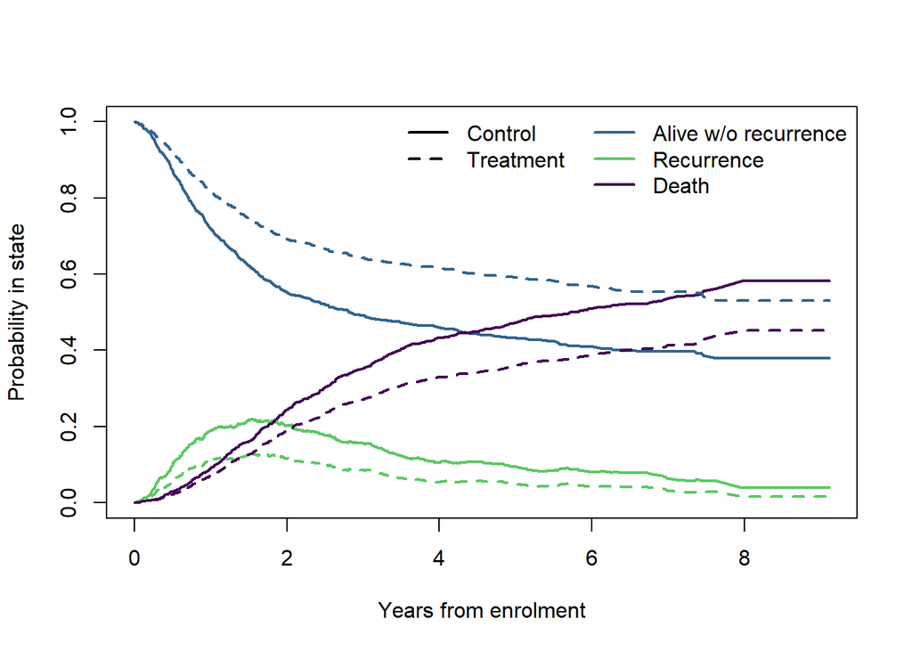

```r
#Store data into one
pr1 <- pr_trt0_red[[1]] %>% mutate(model = "Control")
pr2 <- pr_trt1_red[[1]] %>% mutate(model = "Treatment")

#Plot of probabilities in state
#| fig-width: 2
#| fig-height: 3
matplot(pr1$time,
        pr1[, grep("^pstate", names(pr1))],
        type = "l",
        lwd  = 2,
        lty  = 1,
        xlab = "Years from enrolment",
        ylab = "Probability in state",
        col  = mycolor[c(2,4, 1)])

matlines(pr2$time,
         pr2[, grep("^pstate", names(pr2))],
         type = "l",
         lwd  = 2,
         lty  = 2,
         col  = mycolor[c(2,4, 1)])

# legend for states (colours)
legend("topright",
       legend = c("Alive w/o recurrence", "Recurrence", "Death"),
       col    = mycolor[c(2,4, 1)],
       lty    = 1,
       lwd    = 2,
       bty    = "n")

# legend for models (linetypes)
legend("top",
       legend = c("Control", "Treatment"),
       lty    = c(1, 2),
       lwd    = 2,
       col    = "black",
       bty    = "n")
```

### 11.6 Flexible parametric ‘cause specific’ survival model

Let’s move onto how we can fit flexible parametric survival models for multi-state approach.

**Show R code**

```r
#Treatment variable
cdata_long$trt <- 1*(cdata_long$rx == "Lev+5FU")
cdata_long$age10 <- cdata_long$age/10 # age in decades
cdata_long$male <- 1*(cdata_long$sex ==1) # 0/1: male


#Fit separate models for each transition - as given by msprep
msm_alive_recur <- flexsurvspline(Surv(Tstart, Tstop, status) ~ trt +age10 + male + extent + node4, data=cdata_long, subset=(trans==1), k=1, scale="hazard")
msm_alive_recur
```

```
Call:
flexsurvspline(formula = Surv(Tstart, Tstop, status) ~ trt +
    age10 + male + extent + node4, data = cdata_long, subset = (trans ==
    1), k = 1, scale = "hazard")

Estimates:
        data mean  est       L95%      U95%      se        exp(est)  L95%
gamma0        NA   -0.82768  -1.71303   0.05767   0.45172        NA        NA
gamma1        NA    2.53880   2.22200   2.85560   0.16164        NA        NA
gamma2        NA    0.10153   0.08571   0.11734   0.00807        NA        NA
trt      0.32723   -0.50849  -0.71716  -0.29983   0.10646   0.60140   0.48814
age10    5.97546   -0.02998  -0.10644   0.04649   0.03901   0.97047   0.89903
male     0.52099   -0.08630  -0.26799   0.09538   0.09270   0.91731   0.76491
extent   2.88698    0.52915   0.30772   0.75058   0.11297   1.69749   1.36032
node4    0.27449    0.83298   0.64459   1.02138   0.09612   2.30017   1.90520
        U95%
gamma0        NA
gamma1        NA
gamma2        NA
trt      0.74095
age10    1.04758
male     1.10008
extent   2.11822
node4    2.77704

N = 929,  Events: 468,  Censored: 461
Total time at risk: 3573.892
Log-likelihood = -1199.725, df = 8
AIC = 2415.45
```

**Show R code**

```r
msm_alive_death <- flexsurvspline(Surv(Tstart, Tstop, status) ~ trt +age10 + male + extent + node4, data=cdata_long, subset=(trans==2), k=1, scale="hazard")
msm_alive_death
```

```
Call:
flexsurvspline(formula = Surv(Tstart, Tstop, status) ~ trt +
    age10 + male + extent + node4, data = cdata_long, subset = (trans ==
    2), k = 1, scale = "hazard")

Estimates:
        data mean  est       L95%      U95%      se        exp(est)  L95%
gamma0        NA   -12.2813  -15.9276   -8.6349    1.8604        NA        NA
gamma1        NA     0.7110    0.1039    1.3181    0.3097        NA        NA
gamma2        NA    -0.0515   -0.1288    0.0257    0.0394        NA        NA
trt       0.3272     0.0329   -0.6236    0.6894    0.3350    1.0334    0.5360
age10     5.9755     0.8619    0.4820    1.2419    0.1939    2.3678    1.6193
male      0.5210     0.4345   -0.2230    1.0920    0.3354    1.5442    0.8001
extent    2.8870     0.4540   -0.3056    1.2136    0.3876    1.5746    0.7367
node4     0.2745     0.6487   -0.0843    1.3817    0.3740    1.9130    0.9191
        U95%
gamma0        NA
gamma1        NA
gamma2        NA
trt       1.9925
age10     3.4623
male      2.9801
extent    3.3656
node4     3.9815

N = 929,  Events: 38,  Censored: 891
Total time at risk: 3573.892
Log-likelihood = -195.6232, df = 8
AIC = 407.2465
```

**Show R code**

```r
msm_recur_death <- flexsurvspline(Surv(Tstart, Tstop, status) ~ trt +age10 + male + extent + node4, data=cdata_long, subset=(trans==3), k=1, scale="hazard")
msm_recur_death
```

```
Call:
flexsurvspline(formula = Surv(Tstart, Tstop, status) ~ trt +
    age10 + male + extent + node4, data = cdata_long, subset = (trans ==
    3), k = 1, scale = "hazard")

Estimates:
        data mean  est       L95%      U95%      se        exp(est)  L95%
gamma0        NA   -1.17734  -2.00900  -0.34569   0.42432        NA        NA
gamma1        NA    1.00044   0.36068   1.64021   0.32642        NA        NA
gamma2        NA    0.02605  -0.02633   0.07843   0.02673        NA        NA
trt      0.25427    0.30244   0.07922   0.52567   0.11389   1.35316   1.08244
age10    5.90363    0.10621   0.02803   0.18439   0.03989   1.11205   1.02842
male     0.51068    0.20393   0.00699   0.40087   0.10048   1.22621   1.00702
extent   2.96795    0.09632  -0.11008   0.30271   0.10531   1.10111   0.89577
node4    0.38462    0.42685   0.22293   0.63077   0.10404   1.53242   1.24974
        U95%
gamma0        NA
gamma1        NA
gamma2        NA
trt      1.69159
age10    1.20249
male     1.49312
extent   1.35353
node4    1.87905

N = 468,  Events: 414,  Censored: 54
Total time at risk: 673.5797
Log-likelihood = -582.0249, df = 8
AIC = 1180.05
```

We have fitted a separate model for each transition, using the subset option, and each has 1 internal knots. We can use the above to determine the covariate effects for each transition.

We can then group the transition models together using fmsm, and the associated transition matrix. We can produce the AIC for the entire transition model, allowing us to compare different knot selections.

**Show R code**

```r
#Define transition matrix
tmat_flexsurv <- rbind(c(NA,1,2), c(NA, NA, 3), c(NA, NA, NA))
tmat_flexsurv
```

```
     [,1] [,2] [,3]
[1,]   NA    1    2
[2,]   NA   NA    3
[3,]   NA   NA   NA
```

**Show R code**

```r
#Group transitions together
msm_alltrans <- fmsm(msm_alive_recur, msm_alive_death, msm_recur_death, trans=tmat_flexsurv)
msm_alltrans
```

```
State 1 - State 2
flexsurvspline(formula = Surv(Tstart, Tstop, status) ~ trt +
    age10 + male + extent + node4, data = cdata_long, subset = (trans ==
    1), k = 1, scale = "hazard")

State 1 - State 3
flexsurvspline(formula = Surv(Tstart, Tstop, status) ~ trt +
    age10 + male + extent + node4, data = cdata_long, subset = (trans ==
    2), k = 1, scale = "hazard")

State 2 - State 3
flexsurvspline(formula = Surv(Tstart, Tstop, status) ~ trt +
    age10 + male + extent + node4, data = cdata_long, subset = (trans ==
    3), k = 1, scale = "hazard")
```

**Show R code**

```r
#AIC for entire transition model
AIC(msm_alltrans)
```

```
[1] 4002.746
```

We are now able to use the entire transition model to produce other relevant estimates. Below we are able to produce the cumulative transition-specific intensity function (cumulative hazard) for newdata with set covariates. We can only define one covariate set per msfit.flexsurvreg(), so we would need to re-run with alternate covariate pattern to make any comparisons.

**Show R code**

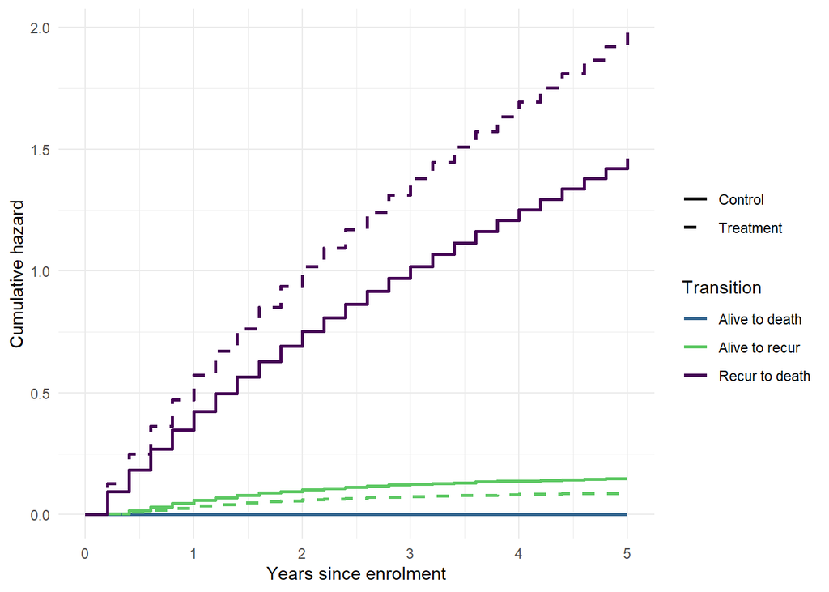

```r
#New data to estimate on - ref level
msm_preddata0 <- data.frame(
  trt = c(0),
  age10=c(4),
  male=c(0),
  extent = c(0),
  node4 = c(0)
)

#Cumulative intensity function - control
cum_trans0<- msfit.flexsurvreg(msm_alltrans, t=seq(0,5,by=0.2), newdata=msm_preddata0, trans=tmat_flexsurv)

#New data to estimate on - treatment
msm_preddata1 <- data.frame(
  trt = c(1),
  age10=c(4),
  male=c(0),
  extent = c(0),
  node4 = c(0)
)

#Cumulative intensity function - treatment
cum_trans1<- msfit.flexsurvreg(msm_alltrans, t=seq(0,5,by=0.2), newdata=msm_preddata1, trans=tmat_flexsurv)

#Store data into one
ct1 <- cum_trans0$Haz %>% mutate(model = "Control")
ct2 <- cum_trans1$Haz %>% mutate(model = "Treatment")

ct_all <- bind_rows(ct1, ct2)
ct_all <- ct_all %>%
  mutate(trans2 = case_when(
    trans==1 ~ "Alive to recur",
    trans==2 ~ "Alive to death",
    trans==3 ~ "Recur to death"
  ))

#Plot - stepped
#| fig-width: 2
#| fig-height: 3
ggplot(ct_all,
       aes(x = time,
           y = Haz,
           colour = factor(trans2),
           linetype = model,
           group = interaction(trans2, model))) +
  geom_step(size = 1) +
  scale_colour_manual(values = mycolor[c(2,4, 1)],
                      name = "Transition") +
  scale_linetype_manual(values = c("solid", "dashed"),
                        name = " ") +
  labs(x = "Years since enrolment", y = "Cumulative hazard") +
  theme_minimal()
```

**Show R code**

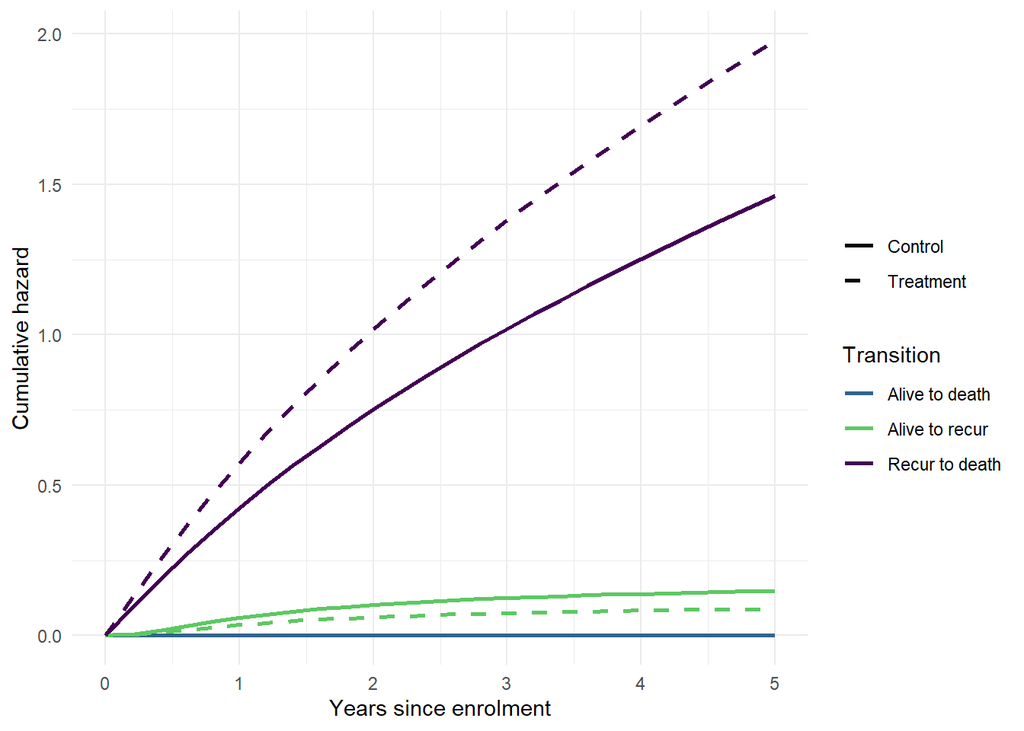

```r
#Plot - smoothed line
#| fig-width: 2
#| fig-height: 3
ggplot(ct_all,
       aes(x = time,
           y = Haz,
           colour = factor(trans2),
           linetype = model,
           group = interaction(trans2, model))) +
  geom_line(size = 1) +
  scale_colour_manual(values = mycolor[c(2,4, 1)],
                      name = "Transition") +
  scale_linetype_manual(values = c("solid", "dashed"),
                        name = " ") +
  labs(x = "Years since enrolment", y = "Cumulative hazard") +
  theme_minimal()
```

From the output of msfit.flexsurvreg(), we can then estimate the probability in state using mstate package.

**Show R code**

```r
#Probability in state - control
prob_instate0 <- probtrans(cum_trans0, predt=0, direction="forward")

#Probability in state - treatment
prob_instate1 <- probtrans(cum_trans1, predt=0, direction="forward")

#Check output for from entry to recur
prob_instate0[[1]]
```

```
   time   pstate1     pstate2      pstate3         se1         se2          se3
1   0.0 1.0000000 0.000000000 0.000000e+00 0.000000000 0.000000000 0.0000000000
2   0.2 0.9954378 0.004514964 4.720236e-05 0.002092941 0.002077587 0.0006344083
3   0.4 0.9834792 0.016033100 4.877184e-04 0.006936808 0.006905761 0.0014656603
4   0.6 0.9691903 0.028929685 1.880012e-03 0.012575597 0.012347112 0.0028184554
5   0.8 0.9552236 0.040550723 4.225664e-03 0.017993031 0.017383212 0.0045509732
6   1.0 0.9426501 0.050024228 7.325672e-03 0.022796605 0.021663482 0.0065269744
7   1.2 0.9317913 0.057258488 1.095020e-02 0.026885602 0.025133068 0.0086261363
8   1.4 0.9225291 0.062573807 1.489708e-02 0.030325812 0.027898984 0.0107590104
9   1.6 0.9146090 0.066378067 1.901290e-02 0.033229931 0.030104199 0.0128656691
10  1.8 0.9077973 0.069013115 2.318958e-02 0.035697939 0.031866974 0.0149079376
11  2.0 0.9018972 0.070750109 2.735274e-02 0.037812125 0.033280116 0.0168632071
12  2.2 0.8967480 0.071799559 3.145241e-02 0.039638455 0.034415300 0.0187196817
13  2.4 0.8922204 0.072320310 3.545934e-02 0.041229380 0.035326851 0.0204735984
14  2.6 0.8882097 0.072432079 3.935821e-02 0.042626600 0.036056315 0.0221264183
15  2.8 0.8846318 0.072227587 4.314066e-02 0.043863395 0.036636458 0.0236821673
16  3.0 0.8814180 0.071779061 4.680289e-02 0.044966479 0.037093367 0.0251461833
17  3.2 0.8785128 0.071143059 5.034417e-02 0.045957431 0.037447993 0.0265243657
18  3.4 0.8758701 0.070364082 5.376584e-02 0.046853801 0.037717306 0.0278227565
19  3.6 0.8734521 0.069477308 5.707060e-02 0.047669965 0.037915168 0.0290472859
20  3.8 0.8712273 0.068510654 6.026201e-02 0.048417774 0.038052987 0.0302036273
21  4.0 0.8691695 0.067486352 6.334417e-02 0.049107063 0.038140224 0.0312971204
22  4.2 0.8672564 0.066422148 6.632146e-02 0.049746042 0.038184777 0.0323327392
23  4.4 0.8654694 0.065332240 6.919840e-02 0.050341603 0.038193279 0.0333150847
24  4.6 0.8637925 0.064227994 7.197952e-02 0.050899567 0.038171335 0.0342483942
25  4.8 0.8622122 0.063118509 7.466930e-02 0.051424873 0.038123705 0.0351365585
26  5.0 0.8607168 0.062011065 7.727210e-02 0.051921730 0.038054453 0.0359831441
```

**Show R code**

```r
prob_instate1[[1]]
```

```
   time   pstate1     pstate2      pstate3         se1         se2          se3
1   0.0 1.0000000 0.000000000 0.000000e+00 0.000000000 0.000000000 0.0000000000
2   0.2 0.9972359 0.002715308 4.878061e-05 0.001323905 0.001323085 0.0005344873
3   0.4 0.9900162 0.009568952 4.148045e-04 0.004234497 0.004298632 0.0011953736
4   0.6 0.9813515 0.017101654 1.546867e-03 0.007633034 0.007662228 0.0022612777
5   0.8 0.9728321 0.023736583 3.431276e-03 0.010926803 0.010798904 0.0035906410
6   1.0 0.9651164 0.028988203 5.895361e-03 0.013877745 0.013489370 0.0050758268
7   1.2 0.9584154 0.032837891 8.746703e-03 0.016415691 0.015687442 0.0066253557
8   1.4 0.9526707 0.035509815 1.181950e-02 0.018571583 0.017448558 0.0081734285
9   1.6 0.9477363 0.037273195 1.499054e-02 0.020407685 0.018854155 0.0096779738
10  1.8 0.9434752 0.038349455 1.817531e-02 0.021980880 0.019973011 0.0111139661
11  2.0 0.9397709 0.038911531 2.131754e-02 0.023338910 0.020860349 0.0124683626
12  2.2 0.9365273 0.039091630 2.438111e-02 0.024520628 0.021559941 0.0137361776
13  2.4 0.9336661 0.038987512 2.734636e-02 0.025557309 0.022105714 0.0149180043
14  2.6 0.9311242 0.038671355 3.020441e-02 0.026474083 0.022524295 0.0160178737
15  2.8 0.9288502 0.038198196 3.295164e-02 0.027291188 0.022837362 0.0170413503
16  3.0 0.9268021 0.037610206 3.558773e-02 0.028024997 0.023062670 0.0179945705
17  3.2 0.9249456 0.036939819 3.811455e-02 0.028688813 0.023214850 0.0188836939
18  3.4 0.9232527 0.036212053 4.053529e-02 0.029293521 0.023306019 0.0197146467
19  3.6 0.9216997 0.035446255 4.285400e-02 0.029848086 0.023346269 0.0204929831
20  3.8 0.9202674 0.034657405 4.507519e-02 0.030359934 0.023344050 0.0212238208
21  4.0 0.9189393 0.033857109 4.720358e-02 0.030835258 0.023306466 0.0219118259
22  4.2 0.9177017 0.033054342 4.924397e-02 0.031279247 0.023239517 0.0225612226
23  4.4 0.9165429 0.032256027 5.120108e-02 0.031696273 0.023148294 0.0231758193
24  4.6 0.9154530 0.031467476 5.307952e-02 0.032090042 0.023037126 0.0237590399
25  4.8 0.9144235 0.030692734 5.488372e-02 0.032463706 0.022909710 0.0243139580
26  5.0 0.9134472 0.029934841 5.661792e-02 0.032819960 0.022769210 0.0248433309
```

**Show R code**

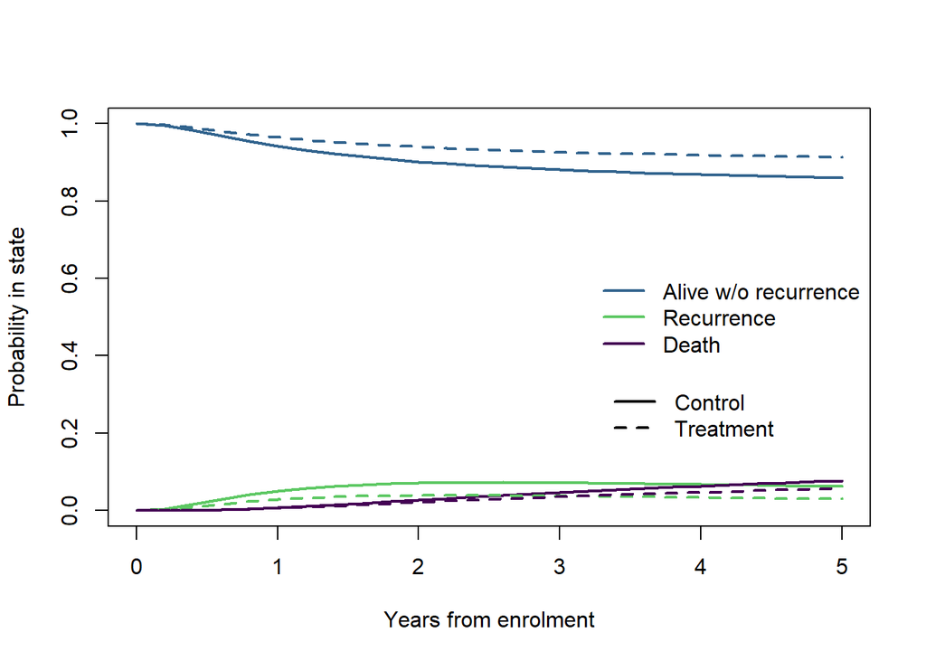

```r
#Store data into one
pr_is1 <- prob_instate0[[1]] %>% mutate(model = "Control")
pr_is2 <- prob_instate1[[1]] %>% mutate(model = "Treatment")

#Plot of probabilities in state
#| fig-width: 2
#| fig-height: 3
matplot(pr_is1$time,
        pr_is1[, grep("^pstate", names(pr1))],
        type = "l",
        lwd  = 2,
        lty  = 1,
        xlab = "Years from enrolment",
        ylab = "Probability in state",
        col  = mycolor[c(2,4, 1)])

matlines(pr_is2$time,
         pr_is2[, grep("^pstate", names(pr2))],
         type = "l",
         lwd  = 2,
         lty  = 2,
         col  = mycolor[c(2,4, 1)])

# legend for states (colours)
legend("right",
       legend = c("Alive w/o recurrence", "Recurrence", "Death"),
       col    = mycolor[c(2,4, 1)],
       lty    = 1,
       lwd    = 2,
       bty    = "n")

# legend for models (linetypes)
legend(3.25,0.35,
       legend = c("Control", "Treatment"),
       lty    = c(1, 2),
       lwd    = 2,
       col    = "black",
       bty    = "n")
```

Similar to what was produced from the `coxph()`, we can produce the expected time in each state. From the below, we are predicting for the reference level.

**Show R code**

```r
#Expected time in states by 8 years - ref level
ELOS(prob_instate0,t=8)
```

```
          in1       in2       in3
from1 7.12111 0.4725666 0.4063239
from2 0.00000 3.0353899 4.9646101
from3 0.00000 0.0000000 8.0000000
```

Starting from the alive state, there would be 7.12 years expected in the alive state, 0.47 years in the recurrence state and 0.41 years in the death state. These can vary as we vary the covariates included. For example, now including the treatment effect below.

**Show R code**

```r
#Expected time in states by 8 years - treatment effect
ELOS(prob_instate1,t=8)
```

```
           in1       in2       in3
from1 7.456105 0.2422315 0.3016635
from2 0.000000 2.2670303 5.7329697
from3 0.000000 0.0000000 8.0000000
```

### 11.7 Flexsurvreg

A special mention about flexsurvreg that this fits standard parametric survival models and does not include splines, as covered in the first lecture for flexible parametric survival.

We are also able to fit these models, under the same basis as covered above, and compare these to select best model fit. There is more functionality in flexsurv to produce subsequent outputs of interest, such as total length of stay in particular states over time and transition probability matrix.

**Show R code**

```r
#Standard parametric survival using Weibull
msm_alive_recur_para <- flexsurvreg(Surv(Tstart, Tstop, status) ~ trt +age10 + male + extent + node4, data=cdata_long, subset=(trans==1), dist="weibull")
msm_alive_recur_para
```

```
Call:
flexsurvreg(formula = Surv(Tstart, Tstop, status) ~ trt + age10 +
    male + extent + node4, data = cdata_long, subset = (trans ==
    1), dist = "weibull")

Estimates:
        data mean  est       L95%      U95%      se        exp(est)  L95%
shape         NA     0.7213    0.6666    0.7805    0.0290        NA        NA
scale         NA    71.4934   22.4423  227.7535   42.2643        NA        NA
trt       0.3272     0.7531    0.4612    1.0449    0.1489    2.1235    1.5860
age10     5.9755     0.0355   -0.0709    0.1419    0.0543    1.0361    0.9315
male      0.5210     0.0949   -0.1570    0.3469    0.1285    1.0996    0.8547
extent    2.8870    -0.7613   -1.0689   -0.4537    0.1570    0.4671    0.3434
node4     0.2745    -1.2116   -1.4796   -0.9436    0.1367    0.2977    0.2277
        U95%
shape         NA
scale         NA
trt       2.8432
age10     1.1524
male      1.4146
extent    0.6353
node4     0.3892

N = 929,  Events: 468,  Censored: 461
Total time at risk: 3573.892
Log-likelihood = -1296.548, df = 7
AIC = 2607.096
```

**Show R code**

```r
msm_alive_death_para <- flexsurvreg(Surv(Tstart, Tstop, status) ~ trt +age10 + male + extent + node4, data=cdata_long, subset=(trans==2), dist="weibull")
msm_alive_death_para
```

```
Call:
flexsurvreg(formula = Surv(Tstart, Tstop, status) ~ trt + age10 +
    male + extent + node4, data = cdata_long, subset = (trans ==
    2), dist = "weibull")

Estimates:
        data mean  est        L95%       U95%       se         exp(est)
shape          NA   1.10e+00   8.41e-01   1.44e+00   1.52e-01         NA
scale          NA   5.14e+04   9.62e+02   2.74e+06   1.04e+05         NA
trt      3.27e-01  -4.07e-02  -6.38e-01   5.56e-01   3.05e-01   9.60e-01
age10    5.98e+00  -7.79e-01  -1.18e+00  -3.80e-01   2.03e-01   4.59e-01
male     5.21e-01  -3.90e-01  -9.94e-01   2.15e-01   3.08e-01   6.77e-01
extent   2.89e+00  -4.11e-01  -1.11e+00   2.86e-01   3.56e-01   6.63e-01
node4    2.74e-01  -5.80e-01  -1.25e+00   9.01e-02   3.42e-01   5.60e-01
        L95%       U95%
shape          NA         NA
scale          NA         NA
trt      5.29e-01   1.74e+00
age10    3.08e-01   6.84e-01
male     3.70e-01   1.24e+00
extent   3.30e-01   1.33e+00
node4    2.87e-01   1.09e+00

N = 929,  Events: 38,  Censored: 891
Total time at risk: 3573.892
Log-likelihood = -196.3709, df = 7
AIC = 406.7417
```

**Show R code**

```r
msm_recur_death_para <-flexsurvreg(Surv(Tstart, Tstop, status) ~ trt +age10 + male + extent + node4, data=cdata_long, subset=(trans==3), dist="weibull")
msm_recur_death_para
```

```
Call:
flexsurvreg(formula = Surv(Tstart, Tstop, status) ~ trt + age10 +
    male + extent + node4, data = cdata_long, subset = (trans ==
    3), dist = "weibull")

Estimates:
        data mean  est        L95%       U95%       se         exp(est)
shape          NA   6.73e-01   5.55e-01   8.16e-01   6.61e-02         NA
scale          NA   4.94e+00   1.54e+00   1.59e+01   2.94e+00         NA
trt      2.54e-01  -4.47e-01  -7.95e-01  -9.97e-02   1.77e-01   6.39e-01
age10    5.90e+00  -1.57e-01  -2.77e-01  -3.81e-02   6.08e-02   8.54e-01
male     5.11e-01  -2.98e-01  -5.96e-01   8.37e-06   1.52e-01   7.42e-01
extent   2.97e+00  -1.50e-01  -4.57e-01   1.57e-01   1.57e-01   8.61e-01
node4    3.85e-01  -6.38e-01  -9.36e-01  -3.40e-01   1.52e-01   5.28e-01
        L95%       U95%
shape          NA         NA
scale          NA         NA
trt      4.52e-01   9.05e-01
age10    7.58e-01   9.63e-01
male     5.51e-01   1.00e+00
extent   6.33e-01   1.17e+00
node4    3.92e-01   7.12e-01

N = 468,  Events: 414,  Censored: 54
Total time at risk: 673.5797
Log-likelihood = -582.4635, df = 7
AIC = 1178.927
```

See below similar coding to above to produce the cumulative hazard and probability in state using these parametric survival models.

**Show R code**

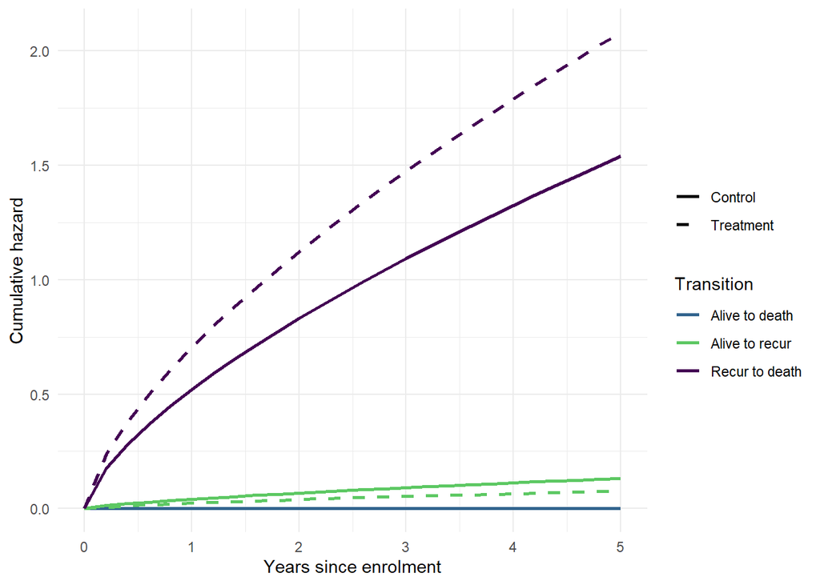

```r
#Create list of transition models
bexp.list <- vector(3, mode="list")
bexp.list[[1]] <- msm_alive_recur_para
bexp.list[[2]] <- msm_alive_death_para
bexp.list[[3]] <- msm_recur_death_para

#Newdata to predict on - control
newdata_prob0 <- data.frame(
  trt = c(0),
  age10=c(4),
  male=c(0),
  extent = c(0),
  node4 = c(0)
)

#Newdata to predict on - treatment
newdata_prob1 <- data.frame(
  trt = c(1),
  age10=c(4),
  male=c(0),
  extent = c(0),
  node4 = c(0)
)

#Cumulative transition specific hazard function - control
cum_thaz0 <- msfit.flexsurvreg(bexp.list, t=seq(0,5,by=0.2), newdata=newdata_prob0, trans=tmat_flexsurv)

#Cumulative transition specific hazard function - treatment
cum_thaz1 <- msfit.flexsurvreg(bexp.list, t=seq(0,5,by=0.2), newdata=newdata_prob1, trans=tmat_flexsurv)

#Store data into one
cth1 <- cum_thaz0$Haz %>% mutate(model = "Control")
cth2 <- cum_thaz1$Haz %>% mutate(model = "Treatment")

cth_all <- bind_rows(cth1, cth2)
cth_all <- cth_all %>%
  mutate(trans2 = case_when(
    trans==1 ~ "Alive to recur",
    trans==2 ~ "Alive to death",
    trans==3 ~ "Recur to death"
  ))


#Plot - smoothed line
#| fig-width: 2
#| fig-height: 3
ggplot(cth_all,
       aes(x = time,
           y = Haz,
           colour = factor(trans2),
           linetype = model,
           group = interaction(trans2, model))) +
  geom_line(size = 1) +
  scale_colour_manual(values = mycolor[c(2,4, 1)],
                      name = "Transition") +
  scale_linetype_manual(values = c("solid", "dashed"),
                        name = " ") +
  labs(x = "Years since enrolment", y = "Cumulative hazard") +
  theme_minimal()
```

**Show R code**

```r
#Probability in state - control
prob_para0 <- probtrans(cum_thaz0, predt=0, direction="forward")

#Probability in state - treatment
prob_para1 <- probtrans(cum_thaz1, predt=0, direction="forward")

#Check output for from entry to recur
prob_para0[[1]]
```

```
   time   pstate1    pstate2      pstate3         se1         se2         se3
1   0.0 1.0000000 0.00000000 0.000000e+00 0.000000000 0.000000000 0.000000000
2   0.2 0.9869684 0.01299746 3.412263e-05 0.005051418 0.005158042 0.001083827
3   0.4 0.9786085 0.01995642 1.435128e-03 0.008163556 0.008091192 0.002148844
4   0.6 0.9714439 0.02531996 3.236179e-03 0.010803317 0.010480564 0.003293903
5   0.8 0.9649710 0.02975294 5.276075e-03 0.013171124 0.012566333 0.004491479
6   1.0 0.9589752 0.03354457 7.480242e-03 0.015351606 0.014448376 0.005722745
7   1.2 0.9533389 0.03685591 9.805150e-03 0.017390881 0.016180204 0.006975399
8   1.4 0.9479888 0.03978901 1.222221e-02 0.019317695 0.017794576 0.008241055
9   1.6 0.9428748 0.04241399 1.471124e-02 0.021151556 0.019313297 0.009513764
10  1.8 0.9379610 0.04478177 1.725728e-02 0.022906497 0.020751761 0.010789177
11  2.0 0.9332203 0.04693084 1.984885e-02 0.024593061 0.022121314 0.012064039
12  2.2 0.9286318 0.04889126 2.247691e-02 0.026219435 0.023430611 0.013335869
13  2.4 0.9241788 0.05068701 2.513419e-02 0.027792147 0.024686435 0.014602759
14  2.6 0.9198476 0.05233767 2.781473e-02 0.029316513 0.025894224 0.015863222
15  2.8 0.9156269 0.05385946 3.051362e-02 0.030796942 0.027058421 0.017116098
16  3.0 0.9115073 0.05526598 3.322673e-02 0.032237142 0.028182719 0.018360477
17  3.2 0.9074806 0.05656881 3.595057e-02 0.033640275 0.029270228 0.019595649
18  3.4 0.9035400 0.05777787 3.868218e-02 0.035009066 0.030323606 0.020821058
19  3.6 0.8996792 0.05890177 4.141900e-02 0.036345884 0.031345144 0.022036279
20  3.8 0.8958931 0.05994799 4.415886e-02 0.037652811 0.032336841 0.023240986
21  4.0 0.8921770 0.06092313 4.689984e-02 0.038931685 0.033300456 0.024434936
22  4.2 0.8885267 0.06183301 4.964030e-02 0.040184143 0.034237550 0.025617956
23  4.4 0.8849384 0.06268278 5.237880e-02 0.041411651 0.035149516 0.026789928
24  4.6 0.8814089 0.06347707 5.511406e-02 0.042615527 0.036037609 0.027950781
25  4.8 0.8779350 0.06422001 5.784499e-02 0.043796967 0.036902964 0.029100482
26  5.0 0.8745141 0.06491532 6.057061e-02 0.044957055 0.037746615 0.030239030
```

**Show R code**

```r
prob_para1[[1]]
```

```
   time   pstate1     pstate2      pstate3         se1         se2          se3
1   0.0 1.0000000 0.000000000 0.0000000000 0.000000000 0.000000000 0.0000000000
2   0.2 0.9924142 0.007550081 0.0000356882 0.002959561 0.003062746 0.0008257068
3   0.4 0.9875132 0.011341122 0.0011456879 0.004795714 0.004762128 0.0016016706
4   0.6 0.9832946 0.014165071 0.0025403516 0.006365378 0.006135321 0.0024214825
5   0.8 0.9794692 0.016435827 0.0040949779 0.007784188 0.007328407 0.0032676241
6   1.0 0.9759141 0.018332336 0.0057536041 0.009100616 0.008401088 0.0041285388
7   1.2 0.9725619 0.019953590 0.0074844616 0.010340903 0.009384970 0.0049971139
8   1.4 0.9693709 0.021361849 0.0092672408 0.011521309 0.010299248 0.0058688029
9   1.6 0.9663125 0.022599535 0.0110879847 0.012652799 0.011156648 0.0067405933
10  1.8 0.9633662 0.023697182 0.0129366247 0.013743218 0.011966146 0.0076104369
11  2.0 0.9605167 0.024677670 0.0148056406 0.014798427 0.012734373 0.0084769187
12  2.2 0.9577521 0.025558674 0.0166892689 0.015822952 0.013466409 0.0093390538
13  2.4 0.9550628 0.026354180 0.0185830035 0.016820382 0.014166259 0.0101961580
14  2.6 0.9524413 0.027075476 0.0204832662 0.017793626 0.014837162 0.0110477617
15  2.8 0.9498810 0.027731818 0.0223871802 0.018745083 0.015481786 0.0118935509
16  3.0 0.9473767 0.028330898 0.0242924097 0.019676759 0.016102370 0.0127333261
17  3.2 0.9449238 0.028879185 0.0261970433 0.020590359 0.016700819 0.0135669731
18  3.4 0.9425183 0.029382172 0.0280995066 0.021487342 0.017278774 0.0143944408
19  3.6 0.9401569 0.029844564 0.0299984973 0.022368973 0.017837669 0.0152157262
20  3.8 0.9378366 0.030270421 0.0318929335 0.023236355 0.018378761 0.0160308616
21  4.0 0.9355548 0.030663273 0.0337819148 0.024090461 0.018903170 0.0168399065
22  4.2 0.9333091 0.031026203 0.0356646907 0.024932149 0.019411893 0.0176429400
23  4.4 0.9310974 0.031361924 0.0375406355 0.025762187 0.019905830 0.0184400558
24  4.6 0.9289179 0.031672828 0.0394092282 0.026581262 0.020385795 0.0192313583
25  4.8 0.9267689 0.031961042 0.0412700359 0.027389992 0.020852528 0.0200169591
26  5.0 0.9246488 0.032228456 0.0431227004 0.028188936 0.021306707 0.0207969749
```

**Show R code**

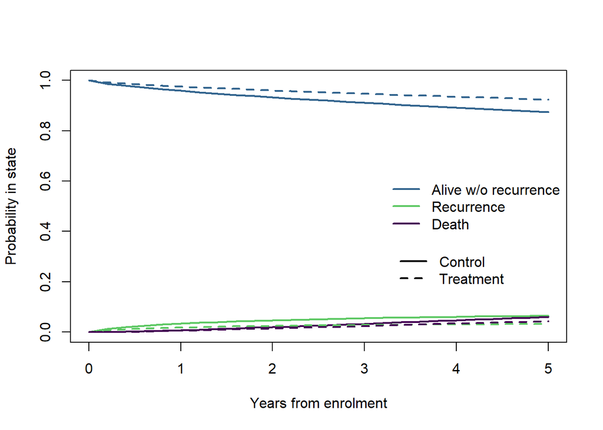

```r
#Store data into one
pr_th1 <- prob_para0[[1]] %>% mutate(model = "Control")
pr_th2 <- prob_para1[[1]] %>% mutate(model = "Treatment")

#Plot of probabilities in state
#| fig-width: 2
#| fig-height: 3
matplot(pr_th1$time,
        pr_th1[, grep("^pstate", names(pr1))],
        type = "l",
        lwd  = 2,
        lty  = 1,
        xlab = "Years from enrolment",
        ylab = "Probability in state",
        col  = mycolor[c(2,4, 1)])

matlines(pr_th2$time,
         pr_th2[, grep("^pstate", names(pr2))],
         type = "l",
         lwd  = 2,
         lty  = 2,
         col  = mycolor[c(2,4, 1)])

# legend for states (colours)
legend("right",
       legend = c("Alive w/o recurrence", "Recurrence", "Death"),
       col    = mycolor[c(2,4, 1)],
       lty    = 1,
       lwd    = 2,
       bty    = "n")

# legend for models (linetypes)
legend(3.25,0.35,
       legend = c("Control", "Treatment"),
       lty    = c(1, 2),
       lwd    = 2,
       col    = "black",
       bty    = "n")
```

The expected mean time in each state is similar to our flexible parametric survival model above.

**Show R code**

```r
#Expected time in states by 8 years - ref level
ELOS(prob_para0, t=8)
```

```
           in1       in2       in3
from1 7.265087 0.4226893 0.3122241
from2 0.000000 2.7754790 5.2245210
from3 0.000000 0.0000000 8.0000000
```

Starting from the alive state, there would be 7.27 years expected in the alive state, 0.42 years in the recurrence state and 0.31 years in the death state. These can vary as we vary the covariates included. For example, now including the treatment effect below. We see there was more time spent in alive state, and less time in recurrence and death.

**Show R code**

```r
#Expected time in states by 8 years - treatment
ELOS(prob_para1, t=8)
```

```
           in1       in2       in3
from1 7.560813 0.2147308 0.2244565
from2 0.000000 2.0004054 5.9995946
from3 0.000000 0.0000000 8.0000000
```

## 12 Transition specific covariates

We have shown above how to run transition specific models, either using `strata(trans)` or `subset(trans==x)`. It’s important to understand that fitting with `strata()` does model the joint likelihood, which sometimes can be computationally difficult. However, there is still functionality to allow for transition-specific covariates.

Fitting with `subset(trans==x)` partitions the likelihood, so it will usually fit faster and more easily. This also allows for transition-specific covariates and it is more accessible to make specific changes to each transition model.

Now let’s demonstrate how we can fit different covariates for each transition.

For the Cox model, we are able to run the below:

**Show R code**

```r
#Cox model with transition specific covariates
summary(cfit_tspec_strata)
```

```
Call:
coxph(formula = Surv(Tstart, Tstop, status) ~ trt.1 + trt.2 +
    trt.3 + age10.1 + age10.2 + age10.3 + male.1 + male.2 + male.3 +
    extent.1 + extent.2 + extent.3 + node4.1 + node4.2 + node4.3 +
    strata(trans), data = cdata_long_exp, id = id)

  n= 2326, number of events= 920

             coef exp(coef) se(coef) robust se      z Pr(>|z|)
trt.1    -0.50755   0.60197  0.10645   0.10792 -4.703 2.57e-06 ***
trt.2     0.02025   1.02046  0.33595   0.33520  0.060   0.9518
trt.3     0.28848   1.33440  0.11431   0.11873  2.430   0.0151 *
age10.1  -0.03166   0.96883  0.03902   0.04202 -0.754   0.4511
age10.2   0.87475   2.39829  0.19574   0.19049  4.592 4.39e-06 ***
age10.3   0.10489   1.11059  0.03995   0.04358  2.407   0.0161 *
male.1   -0.08880   0.91503  0.09270   0.09459 -0.939   0.3478
male.2    0.45226   1.57186  0.33650   0.34432  1.313   0.1890
male.3    0.19556   1.21599  0.10079   0.09401  2.080   0.0375 *
extent.1  0.53260   1.70336  0.11332   0.12229  4.355 1.33e-05 ***
extent.2  0.46911   1.59858  0.38750   0.50819  0.923   0.3559
extent.3  0.08427   1.08793  0.10602   0.11158  0.755   0.4501
node4.1   0.83555   2.30607  0.09614   0.09983  8.370  < 2e-16 ***
node4.2   0.64311   1.90238  0.37459   0.39068  1.646   0.0997 .
node4.3   0.43511   1.54513  0.10423   0.10102  4.307 1.65e-05 ***
---
Signif. codes:  0 '***' 0.001 '**' 0.01 '*' 0.05 '.' 0.1 ' ' 1

         exp(coef) exp(-coef) lower .95 upper .95
trt.1       0.6020     1.6612    0.4872    0.7438
trt.2       1.0205     0.9799    0.5290    1.9684
trt.3       1.3344     0.7494    1.0574    1.6840
age10.1     0.9688     1.0322    0.8922    1.0520
age10.2     2.3983     0.4170    1.6510    3.4837
age10.3     1.1106     0.9004    1.0197    1.2096
male.1      0.9150     1.0929    0.7602    1.1014
male.2      1.5719     0.6362    0.8004    3.0867
male.3      1.2160     0.8224    1.0114    1.4620
extent.1    1.7034     0.5871    1.3403    2.1647
extent.2    1.5986     0.6256    0.5904    4.3282
extent.3    1.0879     0.9192    0.8742    1.3539
node4.1     2.3061     0.4336    1.8963    2.8044
node4.2     1.9024     0.5257    0.8846    4.0911
node4.3     1.5451     0.6472    1.2676    1.8835

Concordance= 0.647  (se = 0.011 )
Likelihood ratio test= 188.7  on 15 df,   p=<2e-16
Wald test            = 173.8  on 15 df,   p=<2e-16
Score (logrank) test = 191.8  on 15 df,   p=<2e-16,   Robust = 154.5  p=<2e-16

  (Note: the likelihood ratio and score tests assume independence of
     observations within a cluster, the Wald and robust score tests do not).
```

**Show R code**

```r
#Remove extent from 1:3 and 2:3
cfit_tspec_strata_remove <- coxph(Surv(Tstart, Tstop, status) ~ trt.1 + trt.2 + trt.3 + age10.1 + age10.2 + age10.3 + male.1 + male.2 + male.3 + extent.1 + node4.1 + node4.2 + node4.3 + strata(trans),
data=cdata_long_exp, id=id)
summary(cfit_tspec_strata_remove)
```

```
Call:
coxph(formula = Surv(Tstart, Tstop, status) ~ trt.1 + trt.2 +
    trt.3 + age10.1 + age10.2 + age10.3 + male.1 + male.2 + male.3 +
    extent.1 + node4.1 + node4.2 + node4.3 + strata(trans), data = cdata_long_exp,
    id = id)

  n= 2326, number of events= 920

             coef exp(coef) se(coef) robust se      z Pr(>|z|)
trt.1    -0.50755   0.60197  0.10645   0.10792 -4.703 2.57e-06 ***
trt.2     0.02536   1.02569  0.33502   0.33216  0.076   0.9391
trt.3     0.28726   1.33277  0.11427   0.11741  2.447   0.0144 *
age10.1  -0.03166   0.96883  0.03902   0.04202 -0.754   0.4511
age10.2   0.87071   2.38860  0.19486   0.18965  4.591 4.41e-06 ***
age10.3   0.10590   1.11171  0.03991   0.04330  2.446   0.0145 *
male.1   -0.08880   0.91503  0.09270   0.09459 -0.939   0.3478
male.2    0.44414   1.55915  0.33562   0.34713  1.279   0.2007
male.3    0.20209   1.22396  0.10039   0.09251  2.184   0.0289 *
extent.1  0.53260   1.70336  0.11332   0.12229  4.355 1.33e-05 ***
node4.1   0.83555   2.30607  0.09614   0.09983  8.370  < 2e-16 ***
node4.2   0.68894   1.99160  0.37345   0.38588  1.785   0.0742 .
node4.3   0.43516   1.54521  0.10429   0.09992  4.355 1.33e-05 ***
---
Signif. codes:  0 '***' 0.001 '**' 0.01 '*' 0.05 '.' 0.1 ' ' 1

         exp(coef) exp(-coef) lower .95 upper .95
trt.1       0.6020     1.6612    0.4872    0.7438
trt.2       1.0257     0.9750    0.5349    1.9668
trt.3       1.3328     0.7503    1.0588    1.6776
age10.1     0.9688     1.0322    0.8922    1.0520
age10.2     2.3886     0.4187    1.6471    3.4639
age10.3     1.1117     0.8995    1.0213    1.2102
male.1      0.9150     1.0929    0.7602    1.1014
male.2      1.5592     0.6414    0.7896    3.0787
male.3      1.2240     0.8170    1.0210    1.4673
extent.1    1.7034     0.5871    1.3403    2.1647
node4.1     2.3061     0.4336    1.8963    2.8044
node4.2     1.9916     0.5021    0.9349    4.2429
node4.3     1.5452     0.6472    1.2704    1.8795

Concordance= 0.647  (se = 0.011 )
Likelihood ratio test= 186.5  on 13 df,   p=<2e-16
Wald test            = 168.4  on 13 df,   p=<2e-16
Score (logrank) test = 190  on 13 df,   p=<2e-16,   Robust = 150.9  p=<2e-16

  (Note: the likelihood ratio and score tests assume independence of
     observations within a cluster, the Wald and robust score tests do not).
```

**Show R code**

```r
#Same results when fitting using subset
cox_alive_recur <- coxph(Surv(Tstart, Tstop, status) ~ trt+age10+male+extent+node4, data=cdata_long, subset=(trans==1), id=id)
summary(cox_alive_recur)
```

```
Call:
coxph(formula = Surv(Tstart, Tstop, status) ~ trt + age10 + male +
    extent + node4, data = cdata_long, subset = (trans == 1),
    id = id)

  n= 929, number of events= 468

           coef exp(coef) se(coef)      z Pr(>|z|)
trt    -0.50755   0.60197  0.10645 -4.768 1.86e-06 ***
age10  -0.03166   0.96883  0.03902 -0.812    0.417
male   -0.08880   0.91503  0.09270 -0.958    0.338
extent  0.53260   1.70336  0.11332  4.700 2.60e-06 ***
node4   0.83555   2.30607  0.09614  8.691  < 2e-16 ***
---
Signif. codes:  0 '***' 0.001 '**' 0.01 '*' 0.05 '.' 0.1 ' ' 1

       exp(coef) exp(-coef) lower .95 upper .95
trt       0.6020     1.6612    0.4886    0.7416
age10     0.9688     1.0322    0.8975    1.0458
male      0.9150     1.0929    0.7630    1.0973
extent    1.7034     0.5871    1.3641    2.1270
node4     2.3061     0.4336    1.9100    2.7842

Concordance= 0.652  (se = 0.013 )
Likelihood ratio test= 128.8  on 5 df,   p=<2e-16
Wald test            = 129.6  on 5 df,   p=<2e-16
Score (logrank) test = 135.9  on 5 df,   p=<2e-16
```

**Show R code**

```r
cox_alive_death <- coxph(Surv(Tstart, Tstop, status) ~ trt+age10+male+node4, data=cdata_long, subset=(trans==2), id=id)
summary(cox_alive_death)
```

```
Call:
coxph(formula = Surv(Tstart, Tstop, status) ~ trt + age10 + male +
    node4, data = cdata_long, subset = (trans == 2), id = id)

  n= 929, number of events= 38

         coef exp(coef) se(coef)     z Pr(>|z|)
trt   0.02536   1.02569  0.33502 0.076   0.9397
age10 0.87071   2.38860  0.19486 4.468 7.88e-06 ***
male  0.44414   1.55915  0.33562 1.323   0.1857
node4 0.68894   1.99160  0.37345 1.845   0.0651 .
---
Signif. codes:  0 '***' 0.001 '**' 0.01 '*' 0.05 '.' 0.1 ' ' 1

      exp(coef) exp(-coef) lower .95 upper .95
trt       1.026     0.9750    0.5319     1.978
age10     2.389     0.4187    1.6303     3.500
male      1.559     0.6414    0.8076     3.010
node4     1.992     0.5021    0.9579     4.141

Concordance= 0.753  (se = 0.044 )
Likelihood ratio test= 27.7  on 4 df,   p=1e-05
Wald test            = 22.79  on 4 df,   p=1e-04
Score (logrank) test = 23.48  on 4 df,   p=1e-04
```

**Show R code**

```r
cox_recur_death <- coxph(Surv(Tstart, Tstop, status) ~ trt+age10+male+node4, data=cdata_long, subset=(trans==3), id=id)
summary(cox_recur_death)
```

```
Call:
coxph(formula = Surv(Tstart, Tstop, status) ~ trt + age10 + male +
    node4, data = cdata_long, subset = (trans == 3), id = id)

  n= 468, number of events= 414

         coef exp(coef) se(coef)     z Pr(>|z|)
trt   0.28726   1.33277  0.11427 2.514  0.01194 *
age10 0.10590   1.11171  0.03991 2.653  0.00797 **
male  0.20209   1.22396  0.10039 2.013  0.04412 *
node4 0.43516   1.54521  0.10429 4.173 3.01e-05 ***
---
Signif. codes:  0 '***' 0.001 '**' 0.01 '*' 0.05 '.' 0.1 ' ' 1

      exp(coef) exp(-coef) lower .95 upper .95
trt       1.333     0.7503     1.065     1.667
age10     1.112     0.8995     1.028     1.202
male      1.224     0.8170     1.005     1.490
node4     1.545     0.6472     1.260     1.896

Concordance= 0.57  (se = 0.014 )
Likelihood ratio test= 29.97  on 4 df,   p=5e-06
Wald test            = 30.37  on 4 df,   p=4e-06
Score (logrank) test = 30.58  on 4 df,   p=4e-06
```

For the flexible parametric survival model, we are able to run the below:

**Show R code**

```r
#Fit separate models for each transition - as given by msprep
msm_alive_recur_cov <- flexsurvspline(Surv(Tstart, Tstop, status) ~ trt +age10 + male + extent + node4, data=cdata_long, subset=(trans==1), k=1, scale="hazard")
msm_alive_recur_cov
```

```
Call:
flexsurvspline(formula = Surv(Tstart, Tstop, status) ~ trt +
    age10 + male + extent + node4, data = cdata_long, subset = (trans ==
    1), k = 1, scale = "hazard")

Estimates:
        data mean  est       L95%      U95%      se        exp(est)  L95%
gamma0        NA   -0.82768  -1.71303   0.05767   0.45172        NA        NA
gamma1        NA    2.53880   2.22200   2.85560   0.16164        NA        NA
gamma2        NA    0.10153   0.08571   0.11734   0.00807        NA        NA
trt      0.32723   -0.50849  -0.71716  -0.29983   0.10646   0.60140   0.48814
age10    5.97546   -0.02998  -0.10644   0.04649   0.03901   0.97047   0.89903
male     0.52099   -0.08630  -0.26799   0.09538   0.09270   0.91731   0.76491
extent   2.88698    0.52915   0.30772   0.75058   0.11297   1.69749   1.36032
node4    0.27449    0.83298   0.64459   1.02138   0.09612   2.30017   1.90520
        U95%
gamma0        NA
gamma1        NA
gamma2        NA
trt      0.74095
age10    1.04758
male     1.10008
extent   2.11822
node4    2.77704

N = 929,  Events: 468,  Censored: 461
Total time at risk: 3573.892
Log-likelihood = -1199.725, df = 8
AIC = 2415.45
```

**Show R code**

```r
msm_alive_death_cov <- flexsurvspline(Surv(Tstart, Tstop, status) ~ trt +age10 + male + node4, data=cdata_long, subset=(trans==2), k=1, scale="hazard")
msm_alive_death_cov
```

```
Call:
flexsurvspline(formula = Surv(Tstart, Tstop, status) ~ trt +
    age10 + male + node4, data = cdata_long, subset = (trans ==
    2), k = 1, scale = "hazard")

Estimates:
        data mean  est       L95%      U95%      se        exp(est)  L95%
gamma0        NA   -10.9443  -13.7686   -8.1200    1.4410        NA        NA
gamma1        NA     0.7080    0.1034    1.3126    0.3085        NA        NA
gamma2        NA    -0.0509   -0.1279    0.0260    0.0393        NA        NA
trt       0.3272     0.0348   -0.6203    0.6899    0.3342    1.0354    0.5378
age10     5.9755     0.8592    0.4806    1.2378    0.1932    2.3614    1.6171
male      0.5210     0.4228   -0.2324    1.0779    0.3343    1.5262    0.7927
node4     0.2745     0.6881   -0.0429    1.4190    0.3729    1.9899    0.9580
        U95%
gamma0        NA
gamma1        NA
gamma2        NA
trt       1.9935
age10     3.4482
male      2.9386
node4     4.1330

N = 929,  Events: 38,  Censored: 891
Total time at risk: 3573.892
Log-likelihood = -196.3676, df = 7
AIC = 406.7351
```

**Show R code**

```r
msm_recur_death_cov <- flexsurvspline(Surv(Tstart, Tstop, status) ~ trt +age10 + male + node4, data=cdata_long, subset=(trans==3), k=1, scale="hazard")
msm_recur_death_cov
```

```
Call:
flexsurvspline(formula = Surv(Tstart, Tstop, status) ~ trt +
    age10 + male + node4, data = cdata_long, subset = (trans ==
    3), k = 1, scale = "hazard")

Estimates:
        data mean  est      L95%     U95%     se       exp(est)  L95%
gamma0       NA    -0.9016  -1.4833  -0.3199   0.2968       NA        NA
gamma1       NA     1.0113   0.3764   1.6462   0.3239       NA        NA
gamma2       NA     0.0271  -0.0250   0.0792   0.0266       NA        NA
trt      0.2543     0.3002   0.0771   0.5234   0.1138   1.3502    1.0802
age10    5.9036     0.1073   0.0292   0.1854   0.0399   1.1133    1.0296
male     0.5107     0.2109   0.0147   0.4071   0.1001   1.2348    1.0148
node4    0.3846     0.4271   0.2230   0.6312   0.1041   1.5328    1.2499
        U95%
gamma0       NA
gamma1       NA
gamma2       NA
trt      1.6877
age10    1.2038
male     1.5025
node4    1.8798

N = 468,  Events: 414,  Censored: 54
Total time at risk: 673.5797
Log-likelihood = -582.4494, df = 7
AIC = 1178.899
```

**Show R code**

```r
#Define transition matrix
tmat_flexsurv <- rbind(c(NA,1,2), c(NA, NA, 3), c(NA, NA, NA))
tmat_flexsurv
```

```
     [,1] [,2] [,3]
[1,]   NA    1    2
[2,]   NA   NA    3
[3,]   NA   NA   NA
```

**Show R code**

```r
#Group transitions together
msm_alltrans_cov <- fmsm(msm_alive_recur_cov, msm_alive_death_cov, msm_recur_death_cov, trans=tmat_flexsurv)
msm_alltrans_cov
```

```
State 1 - State 2
flexsurvspline(formula = Surv(Tstart, Tstop, status) ~ trt +
    age10 + male + extent + node4, data = cdata_long, subset = (trans ==
    1), k = 1, scale = "hazard")

State 1 - State 3
flexsurvspline(formula = Surv(Tstart, Tstop, status) ~ trt +
    age10 + male + node4, data = cdata_long, subset = (trans ==
    2), k = 1, scale = "hazard")

State 2 - State 3
flexsurvspline(formula = Surv(Tstart, Tstop, status) ~ trt +
    age10 + male + node4, data = cdata_long, subset = (trans ==
    3), k = 1, scale = "hazard")
```

## 13 Recurrent events

Multi-state models are also applicable to recurrent events. There are two alternate ways to fit the model with recurrent events. You can define a new transition for each recurrence, or you can include a time-varying covariate to capture this information.

**Note**

When should you fit with transition-specific models for each recurrence compared to time-varying covariate with cumulative count of recurrence?

It really depends on the scenario.

- Few cases with multiple recurrence ➡️ Likely better fit with time-varying covariate
- Covariate effects vary for each recurrence ➡️ Consider transition-specific or interaction terms with time-varying covariate
- Focus on model fit and assumptions to guide decision

We will load in synthetic data that captures relapses and remission in opiod users, from entry into study. The published paper is [accessible here](https://journals.sagepub.com/doi/10.1177/0272989X251395679).

### 13.1 Transition specific to each recurrence

We have provided two forms of the data. The below provides a transition for each recurrence:

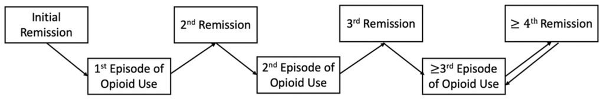

**Show R code**

```r
#Load in transition based recurrence
opiod_msm <- read_csv("https://raw.githubusercontent.com/NicoleDeLaMata/AdvancedSurvival/refs/heads/Data/opiod_msm.csv")

#Set to factor
opiod_msm$homeless <- factor(opiod_msm$homeless, levels = c("No", "Yes"))

#Number of transitions
table(opiod_msm$trans)
```

```
  1   2   3   4   5   6
344 292 235 185 138  96
```

**Show R code**

```r
#Transition types
table(opiod_msm$transition, opiod_msm$trans)
```

```
                         1   2   3   4   5   6
  >=3rd Rel->>=3rd Rem   0   0   0   0   0  96
  1st Rel->1st Rem       0 292   0   0   0   0
  1st Rem->2nd Rel       0   0 235   0   0   0
  2nd Rel->2nd Rem       0   0   0 185   0   0
  2nd Rem->>=3rd Rel     0   0   0   0 138   0
  Init Rem->1st Rel    218   0   0   0   0   0
  Init Rem->Init Rem   126   0   0   0   0   0
```

**Show R code**

```r
#Fit separate models for each transition
op_relap_1 <- flexsurvspline(Surv(Tstart, Tstop, status) ~ trt + homeless, data=opiod_msm, subset=(trans==1), k=1, scale="hazard")
op_relap_1
```

```
Call:
flexsurvspline(formula = Surv(Tstart, Tstop, status) ~ trt +
    homeless, data = opiod_msm, subset = (trans == 1), k = 1,
    scale = "hazard")

Estimates:
             data mean  est      L95%     U95%     se       exp(est)  L95%
gamma0            NA    -3.4030  -3.8849  -2.9211   0.2459       NA        NA
gamma1            NA     1.4337   1.1338   1.7336   0.1530       NA        NA
gamma2            NA     0.1172   0.0507   0.1837   0.0339       NA        NA
trt           0.4041    -0.0274  -0.3003   0.2454   0.1392   0.9729    0.7406
homelessYes   0.2529     0.2206  -0.0774   0.5187   0.1521   1.2469    0.9255
             U95%
gamma0            NA
gamma1            NA
gamma2            NA
trt           1.2781
homelessYes   1.6799

N = 344,  Events: 218,  Censored: 126
Total time at risk: 4175
Log-likelihood = -853.9607, df = 5
AIC = 1717.921
```

**Show R code**

```r
op_remiss_1 <- flexsurvspline(Surv(Tstart, Tstop, status) ~ trt + homeless, data=opiod_msm, subset=(trans==2), k=1, scale="hazard")
op_remiss_1
```

```
Call:
flexsurvspline(formula = Surv(Tstart, Tstop, status) ~ trt +
    homeless, data = opiod_msm, subset = (trans == 2), k = 1,
    scale = "hazard")

Estimates:
             data mean  est      L95%     U95%     se       exp(est)  L95%
gamma0            NA    -1.0609  -1.3748  -0.7471   0.1601       NA        NA
gamma1            NA     1.4863   1.2679   1.7046   0.1114       NA        NA
gamma2            NA     0.0894   0.0426   0.1362   0.0239       NA        NA
trt           0.4212    -0.1370  -0.3701   0.0961   0.1190   0.8720    0.6906
homelessYes   0.2808     0.2029  -0.0535   0.4592   0.1308   1.2249    0.9479
             U95%
gamma0            NA
gamma1            NA
gamma2            NA
trt           1.1009
homelessYes   1.5829

N = 292,  Events: 292,  Censored: 0
Total time at risk: 508
Log-likelihood = -440.2347, df = 5
AIC = 890.4694
```

**Show R code**

```r
op_relap_2 <- flexsurvspline(Surv(Tstart, Tstop, status) ~ trt + homeless, data=opiod_msm, subset=(trans==3), k=1, scale="hazard")
op_relap_2
```

```
Call:
flexsurvspline(formula = Surv(Tstart, Tstop, status) ~ trt +
    homeless, data = opiod_msm, subset = (trans == 3), k = 1,
    scale = "hazard")

Estimates:
             data mean  est      L95%     U95%     se       exp(est)  L95%
gamma0            NA    -2.1650  -3.1099  -1.2201   0.4821       NA        NA
gamma1            NA     1.5354   1.0267   2.0441   0.2595       NA        NA
gamma2            NA     0.1110  -0.0424   0.2644   0.0783       NA        NA
trt           0.4170    -0.1972  -0.4577   0.0633   0.1329   0.8210    0.6327
homelessYes   0.2979    -0.0435  -0.3246   0.2377   0.1434   0.9575    0.7228
             U95%
gamma0            NA
gamma1            NA
gamma2            NA
trt           1.0654
homelessYes   1.2683

N = 235,  Events: 235,  Censored: 0
Total time at risk: 740
Log-likelihood = -500.2961, df = 5
AIC = 1010.592
```

**Show R code**

```r
op_remiss_2 <- flexsurvspline(Surv(Tstart, Tstop, status) ~ trt + homeless, data=opiod_msm, subset=(trans==4), k=1, scale="hazard")
op_remiss_2
```

```
Call:
flexsurvspline(formula = Surv(Tstart, Tstop, status) ~ trt +
    homeless, data = opiod_msm, subset = (trans == 4), k = 1,
    scale = "hazard")

Estimates:
             data mean  est      L95%     U95%     se       exp(est)  L95%
gamma0            NA    -1.3420  -3.0892   0.4052   0.8914       NA        NA
gamma1            NA     1.0971   0.3757   1.8185   0.3680       NA        NA
gamma2            NA    -0.0373  -0.3075   0.2329   0.1379       NA        NA
trt           0.4216    -0.0353  -0.3320   0.2613   0.1514   0.9653    0.7175
homelessYes   0.2973     0.0106  -0.3098   0.3310   0.1635   1.0106    0.7336
             U95%
gamma0            NA
gamma1            NA
gamma2            NA
trt           1.2987
homelessYes   1.3924

N = 185,  Events: 185,  Censored: 0
Total time at risk: 487
Log-likelihood = -363.0881, df = 5
AIC = 736.1762
```

**Show R code**

```r
op_relap_3 <- flexsurvspline(Surv(Tstart, Tstop, status) ~ trt + homeless, data=opiod_msm, subset=(trans==5), k=1, scale="hazard")
op_relap_3
```

```
Call:
flexsurvspline(formula = Surv(Tstart, Tstop, status) ~ trt +
    homeless, data = opiod_msm, subset = (trans == 5), k = 1,
    scale = "hazard")

Estimates:
             data mean  est      L95%     U95%     se       exp(est)  L95%
gamma0            NA    -1.3411  -4.3709   1.6886   1.5458       NA        NA
gamma1            NA     1.0385  -0.0958   2.1727   0.5787       NA        NA
gamma2            NA    -0.2852  -0.8246   0.2541   0.2752       NA        NA
trt           0.4203    -0.1331  -0.4790   0.2127   0.1765   0.8753    0.6194
homelessYes   0.2826    -0.1429  -0.5224   0.2366   0.1936   0.8669    0.5931
             U95%
gamma0            NA
gamma1            NA
gamma2            NA
trt           1.2371
homelessYes   1.2669

N = 138,  Events: 138,  Censored: 0
Total time at risk: 364
Log-likelihood = -267.1885, df = 5
AIC = 544.3769
```

By the last transition, we encounter issues with model fit. You can check out the issues by running this code.

````markdown
```{r}
#Note by this transition, model is having difficulty fitting
op_remiss_3 <- flexsurvspline(Surv(Tstart, Tstop, status) ~ trt + homeless , data=opiod_msm, subset=(trans==6), k=1, scale="hazard")
op_remiss_3

```
````

For teaching purposes, let’s continue with fitting this transition without any internal knots.

**Show R code**

```r
#Note by this transition, model is having difficulty fitting
op_remiss_3 <- flexsurvspline(Surv(Tstart, Tstop, status) ~ trt + homeless , data=opiod_msm, subset=(trans==6), k=0, scale="hazard")
op_remiss_3
```

```
Call:
flexsurvspline(formula = Surv(Tstart, Tstop, status) ~ trt +
    homeless, data = opiod_msm, subset = (trans == 6), k = 0,
    scale = "hazard")

Estimates:
             data mean  est       L95%      U95%      se        exp(est)
gamma0             NA   -12.2252  -15.2594   -9.1910    1.5481        NA
gamma1             NA     4.4874    3.4628    5.5121    0.5228        NA
trt            0.4688    -0.1606   -0.5642    0.2430    0.2059    0.8517
homelessYes    0.2708     0.0539   -0.3987    0.5066    0.2310    1.0554
             L95%      U95%
gamma0             NA        NA
gamma1             NA        NA
trt            0.5688    1.2751
homelessYes    0.6712    1.6596

N = 96,  Events: 96,  Censored: 0
Total time at risk: 465
Log-likelihood = -216.8018, df = 4
AIC = 441.6036
```

Looking at the results, we can see that neither `trt` or `homeless` had any effect on any transition.

We will now join the models together and demonstrate calculation of cumulative hazards.

**Show R code**

```r
#Define transition matrix
op_trans <- rbind(c(NA,1,NA,NA,NA,NA,NA), c(NA,NA,2,NA,NA,NA,NA), c(NA,NA,NA,3,NA,NA,NA),
                  c(NA,NA,NA,NA,4,NA,NA), c(NA,NA,NA,NA,NA,5,NA), c(NA,NA,NA,NA,NA,NA,6),
                  c(NA,NA,NA,NA,NA,NA,NA))
op_trans
```

```
     [,1] [,2] [,3] [,4] [,5] [,6] [,7]
[1,]   NA    1   NA   NA   NA   NA   NA
[2,]   NA   NA    2   NA   NA   NA   NA
[3,]   NA   NA   NA    3   NA   NA   NA
[4,]   NA   NA   NA   NA    4   NA   NA
[5,]   NA   NA   NA   NA   NA    5   NA
[6,]   NA   NA   NA   NA   NA   NA    6
[7,]   NA   NA   NA   NA   NA   NA   NA
```

**Show R code**

```r
#Group transitions together
op_msm_all <- fmsm(op_relap_1, op_remiss_1, op_relap_2, op_remiss_2, op_relap_3, op_remiss_3, trans=op_trans)
op_msm_all
```

```
State 1 - State 2
flexsurvspline(formula = Surv(Tstart, Tstop, status) ~ trt +
    homeless, data = opiod_msm, subset = (trans == 1), k = 1,
    scale = "hazard")

State 2 - State 3
flexsurvspline(formula = Surv(Tstart, Tstop, status) ~ trt +
    homeless, data = opiod_msm, subset = (trans == 2), k = 1,
    scale = "hazard")

State 3 - State 4
flexsurvspline(formula = Surv(Tstart, Tstop, status) ~ trt +
    homeless, data = opiod_msm, subset = (trans == 3), k = 1,
    scale = "hazard")

State 4 - State 5
flexsurvspline(formula = Surv(Tstart, Tstop, status) ~ trt +
    homeless, data = opiod_msm, subset = (trans == 4), k = 1,
    scale = "hazard")

State 5 - State 6
flexsurvspline(formula = Surv(Tstart, Tstop, status) ~ trt +
    homeless, data = opiod_msm, subset = (trans == 5), k = 1,
    scale = "hazard")

State 6 - State 7
flexsurvspline(formula = Surv(Tstart, Tstop, status) ~ trt +
    homeless, data = opiod_msm, subset = (trans == 6), k = 0,
    scale = "hazard")
```

**Show R code**

```r
#Newdata to predict on - control
newdata_op <- data.frame(
  trt = c(0),
  homeless=as.factor(c("No")))

#Cumulative transition specific hazard function - control
chaz_op <- msfit.flexsurvreg(op_msm_all, t=c(1), newdata=newdata_op, trans=op_trans)

#Probability in state - control
prob_op <- probtrans(chaz_op, predt=0, direction="forward")

#Expected time in states by 1 years
ELOS(prob_op, t=1)
```

```
      in1 in2 in3 in4 in5 in6 in7
from1   1   0   0   0   0   0   0
from2   0   1   0   0   0   0   0
from3   0   0   1   0   0   0   0
from4   0   0   0   1   0   0   0
from5   0   0   0   0   1   0   0
from6   0   0   0   0   0   1   0
from7   0   0   0   0   0   0   1
```

### 13.2 Time-varying covariate for recurrence

The data for time-varying covariate for recurrence number is provided below.

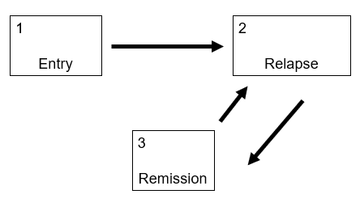

**Show R code**

```r
#Load in recurrence with covariate
opiod <- read_csv("https://raw.githubusercontent.com/NicoleDeLaMata/AdvancedSurvival/refs/heads/Data/opiod.csv")

#Set to factor
opiod$homeless <- factor(opiod$homeless, levels = c("No", "Yes"))

#Number of transitions
table(opiod$trans)
```

```
  1   2   3
344 573 373
```

**Show R code**

```r
#Transition types
table(opiod$transition, opiod$trans)
```

```
                         1   2   3
  >=3rd Rel->>=3rd Rem   0  96   0
  1st Rel->1st Rem       0 292   0
  1st Rem->2nd Rel       0   0 235
  2nd Rel->2nd Rem       0 185   0
  2nd Rem->>=3rd Rel     0   0 138
  Init Rem->1st Rel    218   0   0
  Init Rem->Init Rem   126   0   0
```

Now let’s fit the model with `relapse` giving the time-varying cumulative number of relapses.

**Show R code**

```r
#Fit separate models for each transition
op_to_1recur <- flexsurvspline(Surv(Tstart, Tstop, status) ~ trt + homeless, data=opiod, subset=(trans==1), k=1, scale="hazard")
op_to_1recur
```

```
Call:
flexsurvspline(formula = Surv(Tstart, Tstop, status) ~ trt +
    homeless, data = opiod, subset = (trans == 1), k = 1, scale = "hazard")

Estimates:
             data mean  est      L95%     U95%     se       exp(est)  L95%
gamma0            NA    -3.4030  -3.8849  -2.9211   0.2459       NA        NA
gamma1            NA     1.4337   1.1338   1.7336   0.1530       NA        NA
gamma2            NA     0.1172   0.0507   0.1837   0.0339       NA        NA
trt           0.4041    -0.0274  -0.3003   0.2454   0.1392   0.9729    0.7406
homelessYes   0.2529     0.2206  -0.0774   0.5187   0.1521   1.2469    0.9255
             U95%
gamma0            NA
gamma1            NA
gamma2            NA
trt           1.2781
homelessYes   1.6799

N = 344,  Events: 218,  Censored: 126
Total time at risk: 4175
Log-likelihood = -853.9607, df = 5
AIC = 1717.921
```

**Show R code**

```r
op_to_allremiss <- flexsurvspline(Surv(Tstart, Tstop, status) ~ trt + homeless + relapse, data=opiod, subset=(trans==2), k=1, scale="hazard")
op_to_allremiss
```

```
Call:
flexsurvspline(formula = Surv(Tstart, Tstop, status) ~ trt +
    homeless + relapse, data = opiod, subset = (trans == 2),
    k = 1, scale = "hazard")

Estimates:
             data mean  est      L95%     U95%     se       exp(est)  L95%
gamma0            NA    -0.3690  -0.6740  -0.0641   0.1556       NA        NA
gamma1            NA     1.2252   1.0613   1.3890   0.0836       NA        NA
gamma2            NA     0.0150  -0.0323   0.0622   0.0241       NA        NA
trt           0.4293    -0.0976  -0.2631   0.0679   0.0844   0.9070    0.7686
homelessYes   0.2845     0.1168  -0.0650   0.2986   0.0928   1.1239    0.9370
relapse       1.6579    -0.6086  -0.7319  -0.4852   0.0629   0.5441    0.4810
             U95%
gamma0            NA
gamma1            NA
gamma2            NA
trt           1.0702
homelessYes   1.3479
relapse       0.6156

N = 573,  Events: 573,  Censored: 0
Total time at risk: 1460
Log-likelihood = -1055.46, df = 6
AIC = 2122.92
```

**Show R code**

```r
op_to_allrecur <- flexsurvspline(Surv(Tstart, Tstop, status) ~ trt + homeless + relapse, data=opiod, subset=(trans==3), k=1, scale="hazard")
op_to_allrecur
```

```
Call:
flexsurvspline(formula = Surv(Tstart, Tstop, status) ~ trt +
    homeless + relapse, data = opiod, subset = (trans == 3),
    k = 1, scale = "hazard")

Estimates:
             data mean  est       L95%      U95%      se        exp(est)
gamma0             NA   -1.87329  -2.77316  -0.97342   0.45913        NA
gamma1             NA    1.27590   0.83779   1.71400   0.22353        NA
gamma2             NA    0.00924  -0.12675   0.14522   0.06938        NA
trt           0.41823   -0.16630  -0.37379   0.04118   0.10586   0.84679
homelessYes   0.29223   -0.07995  -0.30535   0.14546   0.11500   0.92317
relapse       1.36997    0.07545  -0.14363   0.29452   0.11178   1.07836
             L95%      U95%
gamma0             NA        NA
gamma1             NA        NA
gamma2             NA        NA
trt           0.68812   1.04204
homelessYes   0.73687   1.15657
relapse       0.86620   1.34249

N = 373,  Events: 373,  Censored: 0
Total time at risk: 1104
Log-likelihood = -770.3233, df = 6
AIC = 1552.647
```

Similar to above, `trt` and `homeless` did not have any effect on the transitions. We do see that relapse is associated with the transition from relapse to remission, where those with more relapses were less likely to transition to remission.

We will now join the models together and demonstrate calculation of cumulative hazards.

**Show R code**

```r
#Define transition matrix
op_trans_sim <- rbind(c(NA,1,NA), c(NA,NA,2), c(NA,3,NA))
op_trans_sim
```

```
     [,1] [,2] [,3]
[1,]   NA    1   NA
[2,]   NA   NA    2
[3,]   NA    3   NA
```

**Show R code**

```r
#Group transitions together
op_simp <- fmsm(op_to_1recur, op_to_allremiss, op_to_allrecur, trans=op_trans_sim)
op_simp
```

```
State 1 - State 2
flexsurvspline(formula = Surv(Tstart, Tstop, status) ~ trt +
    homeless, data = opiod, subset = (trans == 1), k = 1, scale = "hazard")

State 2 - State 3
flexsurvspline(formula = Surv(Tstart, Tstop, status) ~ trt +
    homeless + relapse, data = opiod, subset = (trans == 2),
    k = 1, scale = "hazard")

State 3 - State 2
flexsurvspline(formula = Surv(Tstart, Tstop, status) ~ trt +
    homeless + relapse, data = opiod, subset = (trans == 3),
    k = 1, scale = "hazard")
```

**Show R code**

```r
#Newdata to predict on - control
newdata_op_simp <- data.frame(
  trt = c(0),
  homeless=as.factor(c("No")),
  relapse=c(1))

#Cumulative transition specific hazard function - control
chaz_op_simp <- msfit.flexsurvreg(op_simp, t=seq(0,5,by=0.5), newdata=newdata_op_simp, trans=op_trans_sim)

#Probability in state - control
prob_op_simp <- probtrans(chaz_op_simp, predt=0, direction="forward")
prob_op_simp[[1]]
```

```
   time   pstate1    pstate2     pstate3         se1         se2          se3
1   0.0 1.0000000 0.00000000 0.000000000 0.000000000 0.000000000 0.0000000000
2   0.5 0.9876828 0.01231722 0.000000000 0.004514815 0.004525122 0.0003914221
3   1.0 0.9669849 0.03036342 0.002651697 0.008099410 0.007743807 0.0017210507
4   1.5 0.9417713 0.04853027 0.009698389 0.010876180 0.009795599 0.0036208366
5   2.0 0.9141275 0.06473974 0.021132748 0.013131711 0.011318426 0.0058571245
6   2.5 0.8854779 0.07843315 0.036088963 0.015108582 0.012761940 0.0082055056
7   3.0 0.8567458 0.08982816 0.053426072 0.016948076 0.014281030 0.0105266280
8   3.5 0.8285288 0.09939470 0.072076495 0.018704619 0.015854702 0.0127659150
9   4.0 0.8012066 0.10760624 0.091187176 0.020380363 0.017424582 0.0149253831
10  4.5 0.7750105 0.11484670 0.110142795 0.021955244 0.018960778 0.0170340377
11  5.0 0.7500707 0.12139440 0.128534876 0.023405637 0.020468008 0.0191237666
```

**Show R code**

```r
#Expected time in states by 5 years
ELOS(prob_op_simp, t=5)
```

```
           in1       in2       in3
from1 4.478768 0.3230298 0.1982022
from2 0.000000 2.6707146 2.3292854
from3 0.000000 1.1081758 3.8918242
```

## 14 Data exercise

You have been provided with a [new dataset](https://github.com/NicoleDeLaMata/AdvancedSurvival/blob/Data/waitlist_trans.csv). The state space for this is below.

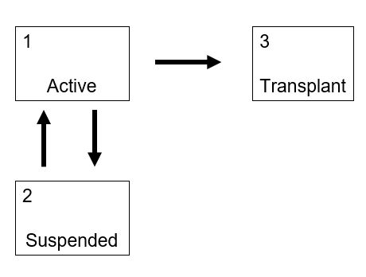

Use the [coding template](https://github.com/NicoleDeLaMata/AdvancedSurvival/blob/Coding/multistate_exercise.R), which includes the variable list, to undertake similar datasteps and analysis above. Produce the:

- Transition-specific Cox model
- Transition-specific flexible parametric survival model with 1 internal knot
- Cumulative hazards plot
- Probability of each cause of death plot

Please refer to the solutions [here](https://nicoledelamata.github.io/AdvancedSurvival/multistate_exercise_solutions.html) and R coding [here](https://github.com/NicoleDeLaMata/AdvancedSurvival/blob/Quarto-docs/multistate_exercise_solutions.qmd) (uploaded following workshop).